# 1 - Problem Statement

### Business Context

Business communities in the United States are facing high demand for human resources, but one of the constant challenges is identifying and attracting the right talent, which is perhaps the most important element in remaining competitive. Companies in the United States look for hard-working, talented, and qualified individuals both locally as well as abroad.

The Immigration and Nationality Act (INA) of the US permits foreign workers to come to the United States to work on either a temporary or permanent basis. The act also protects US workers against adverse impacts on their wages or working conditions by ensuring US employers' compliance with statutory requirements when they hire foreign workers to fill workforce shortages. The immigration programs are administered by the Office of Foreign Labor Certification (OFLC).

OFLC processes job certification applications for employers seeking to bring foreign workers into the United States and grants certifications in those cases where employers can demonstrate that there are not sufficient US workers available to perform the work at wages that meet or exceed the wage paid for the occupation in the area of intended employment.

### Objective

In FY 2016, the OFLC processed 775,979 employer applications for 1,699,957 positions for temporary and permanent labor certifications. This was a nine percent increase in the overall number of processed applications from the previous year. The process of reviewing every case is becoming a tedious task as the number of applicants is increasing every year.

The increasing number of applicants every year calls for a Machine Learning based solution that can help in shortlisting the candidates having higher chances of VISA approval. OFLC has hired the firm EasyVisa for data-driven solutions. You as a data scientist at EasyVisa have to analyze the data provided and, with the help of a classification model:

- Facilitate the process of visa approvals.
- Recommend a suitable profile for the applicants for whom the visa should be certified or denied based on the drivers that significantly influence the case status.

### Data Description

The data contains the different attributes of employee and the employer. The detailed data dictionary is given below.

- case_id: ID of each visa application
- continent: Information of continent the employee
- education_of_employee: Information of education of the employee
- has_job_experience: Does the employee has any job experience? Y= Yes; N = No
- requires_job_training: Does the employee require any job training? Y = Yes; N = No
- no_of_employees: Number of employees in the employer's company
- yr_of_estab: Year in which the employer's company was established
- region_of_employment: Information of foreign worker's intended region of employment in the US.
- prevailing_wage: Average wage paid to similarly employed workers in a specific occupation in the area of intended employment. The purpose of the prevailing wage is to ensure that the foreign worker is not underpaid compared to other workers offering the same or similar service in the same area of employment.
- unit_of_wage: Unit of prevailing wage. Values include Hourly, Weekly, Monthly, and Yearly.
- full_time_position: Is the position of work full-time? Y = Full Time Position; N = Part Time Position
- case_status: Flag indicating if the Visa was certified or denied

# 2 - Initiall Preparation

## Importing the necessary libraries

```python
# Import necessary libraries for data analysis
import pandas as pd
import numpy as np
import math
import matplotlib.pyplot as plt
import seaborn as sns
import os
import sys
from functools import partial

# Import libraries for splitting data and model tuning
from sklearn.model_selection import train_test_split, cross_val_score, RandomizedSearchCV, GridSearchCV, StratifiedKFold

# Import libraries for metric evaluation
from sklearn import metrics
from sklearn.metrics import confusion_matrix, accuracy_score, precision_score, recall_score, f1_score

# Import libraries for model building
from sklearn.tree import DecisionTreeClassifier
from sklearn.ensemble import BaggingClassifier, RandomForestClassifier, AdaBoostClassifier, GradientBoostingClassifier
from xgboost import XGBClassifier

# Import libraries for data sampling
from imblearn.over_sampling import SMOTE
from imblearn.under_sampling import RandomUnderSampler

# Manage Warnings
import warnings
```

```python
# Manage Warnings
warnings.filterwarnings('ignore')

# Manage MallocStackLogging warnings in Python
def filter_malloc_warnings(original_write, message):
    if "MallocStackLogging" not in message:
        original_write(message)

original_stderr = sys.stderr.write
sys.stderr.write = partial(filter_malloc_warnings, original_stderr)
```

## Setting Constant Values

```python
# Define the path to the data as constants
FOLDER  = "data/"
FILE = "EasyVisa.csv"
# Set the random seed for reproducibility
RS = 1
```

## Loading the Dataset

```python
# Read the data and store it
data = pd.read_csv(FOLDER + FILE)
#Create a copy of the data, in order to do data validations and keep the original data
df = data.copy()
```

# 3 - Overview of the Dataset

#### View the first and last 5 rows of the dataset

```python
# Sample the first rows of the data
df.head()
```

|  | case_id | continent | education_of_employee | has_job_experience | requires_job_training | no_of_employees | yr_of_estab | region_of_employment | prevailing_wage | unit_of_wage | full_time_position | case_status |
| --- | --- | --- | --- | --- | --- | --- | --- | --- | --- | --- | --- | --- |
| 0 | EZYV01 | Asia | High School | N | N | 14513 | 2007 | West | 592.2029 | Hour | Y | Denied |
| 1 | EZYV02 | Asia | Master's | Y | N | 2412 | 2002 | Northeast | 83425.6500 | Year | Y | Certified |
| 2 | EZYV03 | Asia | Bachelor's | N | Y | 44444 | 2008 | West | 122996.8600 | Year | Y | Denied |
| 3 | EZYV04 | Asia | Bachelor's | N | N | 98 | 1897 | West | 83434.0300 | Year | Y | Denied |
| 4 | EZYV05 | Africa | Master's | Y | N | 1082 | 2005 | South | 149907.3900 | Year | Y | Certified |

```python
# Sample the last rows of the data
df.tail()
```

|  | case_id | continent | education_of_employee | has_job_experience | requires_job_training | no_of_employees | yr_of_estab | region_of_employment | prevailing_wage | unit_of_wage | full_time_position | case_status |
| --- | --- | --- | --- | --- | --- | --- | --- | --- | --- | --- | --- | --- |
| 25475 | EZYV25476 | Asia | Bachelor's | Y | Y | 2601 | 2008 | South | 77092.57 | Year | Y | Certified |
| 25476 | EZYV25477 | Asia | High School | Y | N | 3274 | 2006 | Northeast | 279174.79 | Year | Y | Certified |
| 25477 | EZYV25478 | Asia | Master's | Y | N | 1121 | 1910 | South | 146298.85 | Year | N | Certified |
| 25478 | EZYV25479 | Asia | Master's | Y | Y | 1918 | 1887 | West | 86154.77 | Year | Y | Certified |
| 25479 | EZYV25480 | Asia | Bachelor's | Y | N | 3195 | 1960 | Midwest | 70876.91 | Year | Y | Certified |

### Size and Datatype

```python
# Get the number of columns and rows
df.shape
```

```
(25480, 12)
```

- The data has 25,480 rows and 12 columns.

#### Check the data types of the columns for the dataset

```python
# Get the information of each column
df.info()
```

```
<class 'pandas.core.frame.DataFrame'>
RangeIndex: 25480 entries, 0 to 25479
Data columns (total 12 columns):
 #   Column                 Non-Null Count  Dtype
---  ------                 --------------  -----
 0   case_id                25480 non-null  object
 1   continent              25480 non-null  object
 2   education_of_employee  25480 non-null  object
 3   has_job_experience     25480 non-null  object
 4   requires_job_training  25480 non-null  object
 5   no_of_employees        25480 non-null  int64
 6   yr_of_estab            25480 non-null  int64
 7   region_of_employment   25480 non-null  object
 8   prevailing_wage        25480 non-null  float64
 9   unit_of_wage           25480 non-null  object
 10  full_time_position     25480 non-null  object
 11  case_status            25480 non-null  object
dtypes: float64(1), int64(2), object(9)
memory usage: 2.3+ MB
```

- The data has 3 numeric variables and 9 variables with object type.
- Number of employees and Year of establishment are integers.
- Prevailing Wage is float.

## Understanding the Variables

#### Case ID

```python
# Unique values in Case ID
df["case_id"].nunique()
```

```
25480
```

- Case ID has 25480 unique values. Which means that each row represents a different case.
- These variable is used to identify each case and doesn't provide statistical information and is not usefull for generating a model.
- This variable will be dropped.

#### Continent

```python
# Look at the value counts for each category in continent
region_stats = pd.DataFrame(df["continent"].value_counts())
region_stats["percentage"] = round((df["continent"].value_counts() / df["continent"].shape[0]) * 100, 2)
region_stats
```

| continent | count | percentage |
| --- | --- | --- |
| Asia | 16861 | 66.17 |
| Europe | 3732 | 14.65 |
| North America | 3292 | 12.92 |
| South America | 852 | 3.34 |
| Africa | 551 | 2.16 |
| Oceania | 192 | 0.75 |

- This is a categorical variable. It has 6 categories representing a continent (Asia, Europe, North America, South America, Africa, Oceania).
- Asia is the most popular category, followed by Europe and North America.
- The least popular continents are South America, Africa and Oceania.

#### Education of Employee

```python
# Look at the value counts for each category in Education of Employee
edu_stats = pd.DataFrame(df["education_of_employee"].value_counts())
edu_stats["percentage"] = round((df["education_of_employee"].value_counts() / df["education_of_employee"].shape[0]) * 100, 2)
edu_stats
```

| education_of_employee | count | percentage |
| --- | --- | --- |
| Bachelor's | 10234 | 40.16 |
| Master's | 9634 | 37.81 |
| High School | 3420 | 13.42 |
| Doctorate | 2192 | 8.60 |

- This is a categorical variable. It has 4 categories that correspond to the highest educational degree hold by an employee (Doctorate, Master's, Bachelor's, High School).
- The most common highest education is Bachelor's degree, followed by Master's degree.
- The less common highest educations are High School and Doctorate.

#### Has Job Experience

```python
job_stats = pd.DataFrame(df["has_job_experience"].value_counts())
job_stats["Percentage"] = round((df["has_job_experience"].value_counts() / df["has_job_experience"].shape[0]) * 100, 2)
job_stats
```

| has_job_experience | count | Percentage |
| --- | --- | --- |
| Y | 14802 | 58.09 |
| N | 10678 | 41.91 |

- This variable only has 2 categories (Yes / No).
- 58.1% of applicants have job experience.
- 41.91% of applicants don't have job experience.
- This variable will need to be converted to binary (1/0).

#### Requires Job Training

```python
job_train_stats = pd.DataFrame(df["requires_job_training"].value_counts())
job_train_stats["Percentage"] = round((df["requires_job_training"].value_counts() / df["requires_job_training"].shape[0]) * 100, 2)
job_train_stats
```

| requires_job_training | count | Percentage |
| --- | --- | --- |
| N | 22525 | 88.4 |
| Y | 2955 | 11.6 |

- This variable only has 2 categories (Yes / No).
- 88.4% of applicants don't require job training.
- 11.6% of applicants require job training.
- This variable will need to be converted to binary (1/0).

#### Full Time position

```python
full_stats = pd.DataFrame(df["full_time_position"].value_counts())
full_stats["percentage"] = round((df["full_time_position"].value_counts() / df["full_time_position"].shape[0]) * 100, 2)
full_stats
```

| full_time_position | count | percentage |
| --- | --- | --- |
| Y | 22773 | 89.38 |
| N | 2707 | 10.62 |

- This variable only has 2 categories (Yes / No).
- 89.38% of applicants are for full time positions.
- 10.62% of applicants are for part time positions.
- This variable will need to be converted to binary (1/0).

#### Case Status

```python
case_stats = pd.DataFrame(df["case_status"].value_counts())
case_stats["percentage"] = round((df["case_status"].value_counts() / df["case_status"].shape[0]) * 100, 2)
case_stats
```

| case_status | count | percentage |
| --- | --- | --- |
| Certified | 17018 | 66.79 |
| Denied | 8462 | 33.21 |

- This is our target variable. As seen it is a classification variable.
- The target variable has 2 classes Certified and Denied.
- Certified has a 66.79% and Denied 33.21%.
- There is some imbalance in the data.
- This variable will need to be converted to binary (1/0).

#### Number of Employees

```python
# Unique values in number of employees
df["no_of_employees"].nunique()
```

```
7105
```

```python
# View the range of number of employees
df["no_of_employees"].sort_values()
```

```
14146       -26
9872        -26
2918        -26
6634        -26
16883       -26
          ...
9587     547172
11317    579004
20345    581468
1345     594472
21339    602069
Name: no_of_employees, Length: 25480, dtype: int64
```

```python
# Count the number of rows that have negative number of employees
sum(df["no_of_employees"] < 0)
```

```
33
```

- This variable has 7105 unique values.
- The range for this variable goes from -26 to 602,069 employees.
- There seems to be an error on 33 aplications as they have negative number of employees. As there can't be a negative number of employees this will be change to positive numbers.
- Some employeers share the same number of employees, probably because it refers to the same employeer.
- This variable gives insight on the size of the company where the applicant is looking for employment.

#### Year of Establishment

```python
# Count and look at the range
df["yr_of_estab"].value_counts().sort_index()
```

```
yr_of_estab
1800     16
1801     12
1804     18
1807      6
1809      9
       ...
2012    492
2013    533
2014    175
2015     64
2016     23
Name: count, Length: 199, dtype: int64
```

- There are 199 different years in the data.
- The range when the employeers were established goes from 1800 to 2016.

#### Region of Employment

```python
region_stats = pd.DataFrame(df["region_of_employment"].value_counts())
region_stats["percentage"] = round((df["region_of_employment"].value_counts() / df["region_of_employment"].shape[0]) * 100, 2)
region_stats
```

| region_of_employment | count | percentage |
| --- | --- | --- |
| Northeast | 7195 | 28.24 |
| South | 7017 | 27.54 |
| West | 6586 | 25.85 |
| Midwest | 4307 | 16.90 |
| Island | 375 | 1.47 |

- This variable has 5 categories (Northeast, South, West, Midwest, Island).
- The most common region is Northeast with 28.24%, followed by South with 27.54% and then by West with 25.85%.
- Midwest is not as common with 16.90% and the least common is Island with only 1.47%.

#### Prevailing Wage

```python
df["prevailing_wage"].describe()
```

```
count     25480.000000
mean      74455.814592
std       52815.942327
min           2.136700
25%       34015.480000
50%       70308.210000
75%      107735.512500
max      319210.270000
Name: prevailing_wage, dtype: float64
```

- The range of this variable is big. As it goes from $2.14 USD to 319,210.27 USD
- This might be beacuse the next column specifies the unit of wage. So it is disimilar to compare a wage in hours to a wage expressed yearly.
- This variable might benefit to convert to the same unit. And express everything in yearly wage.

#### Unit of Wage

```python
wage_stats = pd.DataFrame(df["unit_of_wage"].value_counts())
wage_stats["percentage"] = round((df["unit_of_wage"].value_counts() / df["unit_of_wage"].shape[0]) * 100, 2)
wage_stats
```

| unit_of_wage | count | percentage |
| --- | --- | --- |
| Year | 22962 | 90.12 |
| Hour | 2157 | 8.47 |
| Week | 272 | 1.07 |
| Month | 89 | 0.35 |

- This variable indicates if prevailing wage is express Yearly, Monthly, Weekly or by the Hour.
- 90.12% is expressed yearly, and just 9.88% of the wages are expressed diferently. So 2518 datapoints are not expressed yearly.

# 4 - Data Preprocessing

### Duplicated Datapoints

```python
# Check for duplicates
df.duplicated().sum()
```

```
np.int64(0)
```

- There is no duplicates. Each row corresponds to a unique visa application

### Missing Values

```python
# checking missing values in the data
df.isna().sum()
```

```
case_id                  0
continent                0
education_of_employee    0
has_job_experience       0
requires_job_training    0
no_of_employees          0
yr_of_estab              0
region_of_employment     0
prevailing_wage          0
unit_of_wage             0
full_time_position       0
case_status              0
dtype: int64
```

- There are no missing vlaues in the data.

### Drop Identifier Column - Case ID

Case ID is only used to identify each record, it will not provide statistical meaning and it will not help the model with predictions.

As such this column will be dropped.

```python
# Drop column Case ID
df.drop("case_id", axis=1, inplace=True)
df.head()
```

|  | continent | education_of_employee | has_job_experience | requires_job_training | no_of_employees | yr_of_estab | region_of_employment | prevailing_wage | unit_of_wage | full_time_position | case_status |
| --- | --- | --- | --- | --- | --- | --- | --- | --- | --- | --- | --- |
| 0 | Asia | High School | N | N | 14513 | 2007 | West | 592.2029 | Hour | Y | Denied |
| 1 | Asia | Master's | Y | N | 2412 | 2002 | Northeast | 83425.6500 | Year | Y | Certified |
| 2 | Asia | Bachelor's | N | Y | 44444 | 2008 | West | 122996.8600 | Year | Y | Denied |
| 3 | Asia | Bachelor's | N | N | 98 | 1897 | West | 83434.0300 | Year | Y | Denied |
| 4 | Africa | Master's | Y | N | 1082 | 2005 | South | 149907.3900 | Year | Y | Certified |

### Convert Positive Numbers - Number of Employees

In the Data Overview it was identified that this variable contains negative numbers. It is possible that a company doesn't have employees. But it is surley and error to have a negative number of employees. This is most likely a capture error, as such all negative numbers will be converted to positive.

```python
# Convert to positive numbers.
df["no_of_employees"] = abs(df["no_of_employees"])
df["no_of_employees"].sort_values()
```

```
17006        11
14022        11
378          11
16157        11
7761         11
          ...
9587     547172
11317    579004
20345    581468
1345     594472
21339    602069
Name: no_of_employees, Length: 25480, dtype: int64
```

#### Convert to Categories

```python
# Convert object types to category
cat_col = ["continent", "education_of_employee", "has_job_experience", "requires_job_training", "region_of_employment", "unit_of_wage", "full_time_position", "case_status"]
df[cat_col] = data[cat_col].astype("category")
```

## Review After Data Preprocessing

```python
# Observe the data types of the columns after data preparation for EDA
df.info()
```

```
<class 'pandas.core.frame.DataFrame'>
RangeIndex: 25480 entries, 0 to 25479
Data columns (total 11 columns):
 #   Column                 Non-Null Count  Dtype
---  ------                 --------------  -----
 0   continent              25480 non-null  category
 1   education_of_employee  25480 non-null  category
 2   has_job_experience     25480 non-null  category
 3   requires_job_training  25480 non-null  category
 4   no_of_employees        25480 non-null  int64
 5   yr_of_estab            25480 non-null  int64
 6   region_of_employment   25480 non-null  category
 7   prevailing_wage        25480 non-null  float64
 8   unit_of_wage           25480 non-null  category
 9   full_time_position     25480 non-null  category
 10  case_status            25480 non-null  category
dtypes: category(8), float64(1), int64(2)
memory usage: 797.7 KB
```

- The dataframe has reduce its memory usage, as a result of dropping one column and transforming object datatypes to categories.

# 5 - Exploratory Data Analysis (EDA)

#### Plot Functions

```python
def plot_numerical_distributions(data, numerical_features, hue=None, figsize=(16, 12), dpi=100, bins=30, palette="viridis", plot_style="whitegrid", show_median=True):

    # Set style and palette
    sns.set_style(plot_style)
    sns.set_palette(palette)

    # Calculate grid dimensions
    n_cols = 2
    n_rows = (len(numerical_features) // n_cols) + (1 if len(numerical_features) % n_cols else 0)

    # Create figure
    fig = plt.figure(figsize=figsize, dpi=dpi)
    fig.suptitle('Distribution Analysis', y=1.02, fontsize=16, fontweight='bold')

    for i, feature in enumerate(numerical_features, 1):
        ax = plt.subplot(n_rows, n_cols, i)

        # Plot histogram with KDE
        sns.histplot(data=data, x=feature, hue=hue, kde=True, bins=bins, edgecolor='white', linewidth=0.5, stat='count', alpha=0.7)

        # Add median line
        if show_median:
            median = data[feature].median()
            ax.axvline(median, color='red', linestyle='--', linewidth=1.5)
            x_offset = 0.02 * (ax.get_xlim()[1] - ax.get_xlim()[0])  # 2% of x-axis range
            ax.text(median + x_offset, ax.get_ylim()[1]*0.9, f'Median: {median:.1f}', color='red', va='top')

        # Formatting
        ax.set_title(f'{feature} Distribution', pad=10)
        ax.set_xlabel('')
        ax.grid(alpha=0.3)

    plt.tight_layout()

    return fig
```

```python
def plot_numerical_boxplots(data, numerical_features, figsize=(16, 12), palette="viridis", plot_style="whitegrid", showfliers=True, notch=False, orient="v", hue=None):

    # Set visual style
    sns.set_style(plot_style)
    plt.rcParams['font.size'] = 12

    # Calculate grid dimensions
    n_cols = 2
    n_rows = (len(numerical_features) // n_cols) + (1 if len(numerical_features) % n_cols else 0)

    # Initialize figure
    fig = plt.figure(figsize=figsize, dpi=100, layout="constrained")
    fig.suptitle('Numerical Features Distribution Analysis (Boxplots)', fontsize=18, fontweight='bold', y=1.02)

    # Create subplots
    for idx, feature in enumerate(numerical_features, start=1):
        ax = fig.add_subplot(n_rows, n_cols, idx)

        # Plot boxplot with enhanced aesthetics
        sns.boxplot(
            data=data,
            x=feature if orient == "v" else None,
            y=None if orient == "v" else feature,
            hue=hue,
            palette=palette,
            width=0.6,
            showfliers=showfliers,
            notch=notch,
            linewidth=1.5,
            fliersize=3,
            saturation=0.8
        )



        # Add mean marker
        mean_val = data[feature].mean()
        if orient == "v":
            ax.axvline(mean_val, color='red', linestyle='--', linewidth=1.2, label=f'Mean: {mean_val:.1f}')
        else:
            ax.axhline(mean_val, color='red', linestyle='--', linewidth=1.2, label=f'Mean: {mean_val:.1f}')
        ax.legend(loc='upper right')

        # Format subplot
        ax.set_title(f'{feature} Distribution', pad=12, fontweight='semibold')
        if orient == "v":
            ax.set_ylabel('Value', fontsize=12)
        else:
            ax.set_xlabel('Value', fontsize=12)
        ax.grid(visible=True, alpha=0.2, axis='y' if orient == "v" else 'x')

        # Remove top/right spines
        sns.despine(ax=ax, top=True, right=True)

    # Add figure caption
    caption = "Note: Red dashed line shows mean value. Box shows IQR (25th-75th percentile)"
    if showfliers:
        caption += ". Points show outliers."
    if hue:
        caption += f" Grouped by {hue}."
    fig.text(
        0.5, 0.01,
        caption,
        ha='center',
        fontsize=12,
        color='dimgray'
    )

    return fig
```

```python
def plot_categorical_distributions(data, categorical_features, hue="",figsize=(16, 18), palette="viridis", plot_style="whitegrid", annotate=True, rotate_labels=False):
    # Set visual style
    sns.set_style(plot_style)
    plt.rcParams['font.size'] = 12

    # Calculate grid dimensions
    n_cols = 2
    n_rows = (len(categorical_features) // n_cols) + (1 if len(categorical_features) % n_cols else 0)

    # Initialize figure
    fig = plt.figure(figsize=figsize, dpi=100, layout="constrained")
    fig.suptitle('Distribution Analysis', fontsize=18, fontweight='bold', y=1.02)

    # Create subplots
    for idx, feature in enumerate(categorical_features, start=1):
        ax = fig.add_subplot(n_rows, n_cols, idx)

        # Plot with improved aesthetics
        if hue:
            # If hue is provided, use countplot with hue
            plot = sns.countplot(data=data, x=feature, hue=hue, palette=palette, edgecolor='black', linewidth=0.5, alpha=0.85)
        else:
            # If no hue is provided, use countplot without hue
            plot = sns.countplot(data=data, x=feature, palette=palette, edgecolor='black', linewidth=0.5, alpha=0.85, order=data[feature].value_counts().index)  # Sort by frequency

        # Add count annotations
        if annotate:
            for p in ax.patches:
                ax.annotate(
                    f'{p.get_height():,.0f}',
                    (p.get_x() + p.get_width() / 2., p.get_height()),
                    ha='center', va='center',
                    xytext=(0, 5),
                    textcoords='offset points',
                    fontsize=10
                )

        # Rotate labels if needed
        if rotate_labels:
            plt.setp(ax.get_xticklabels(), rotation=45, ha='right')

        # Format subplot
        ax.set_title(f'{feature} Distribution', pad=12, fontweight='semibold')
        ax.set_xlabel('')
        ax.set_ylabel('Count', fontsize=12)
        ax.grid(visible=True, alpha=0.2, axis='y')

        # Remove top/right spines
        sns.despine(ax=ax, top=True, right=True)

    return fig
```

## Statistical Analysis

```python
# Observe the statistical summary of the numeric variables
df.describe().T
```

|  | count | mean | std | min | 25% | 50% | 75% | max |
| --- | --- | --- | --- | --- | --- | --- | --- | --- |
| no_of_employees | 25480.0 | 5667.089207 | 22877.917453 | 11.0000 | 1022.00 | 2109.00 | 3504.0000 | 602069.00 |
| yr_of_estab | 25480.0 | 1979.409929 | 42.366929 | 1800.0000 | 1976.00 | 1997.00 | 2005.0000 | 2016.00 |
| prevailing_wage | 25480.0 | 74455.814592 | 52815.942327 | 2.1367 | 34015.48 | 70308.21 | 107735.5125 | 319210.27 |

#### Observations:

Further analysis will be provides in the univariate and bivariate analysis.

```python
# Observe the statistical summary of the category variables
df.describe(include="category").T
```

|  | count | unique | top | freq |
| --- | --- | --- | --- | --- |
| continent | 25480 | 6 | Asia | 16861 |
| education_of_employee | 25480 | 4 | Bachelor's | 10234 |
| has_job_experience | 25480 | 2 | Y | 14802 |
| requires_job_training | 25480 | 2 | N | 22525 |
| region_of_employment | 25480 | 5 | Northeast | 7195 |
| unit_of_wage | 25480 | 4 | Year | 22962 |
| full_time_position | 25480 | 2 | Y | 22773 |
| case_status | 25480 | 2 | Certified | 17018 |

#### Observations:

- Most applicants come from Asia.
- Most applications are for the US Northeast region.
- The most common education is Bachelor's degree.
- Most applications are for full time positions amd are given in yearly salary.

Further analysis will be provides in the univariate and bivariate analysis.

## Univariate Analysis

### Numerical Variables Distribution

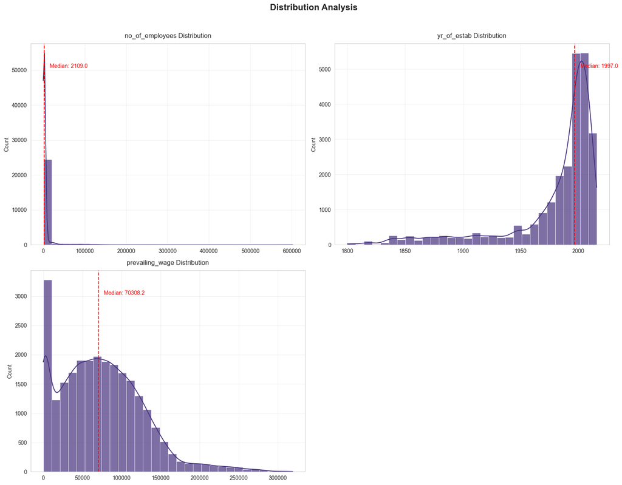

```python
# Plot Histograms for numerical variables
column_numerical = ["no_of_employees", "yr_of_estab", "prevailing_wage"]
fig = plot_numerical_distributions(df, column_numerical)
```

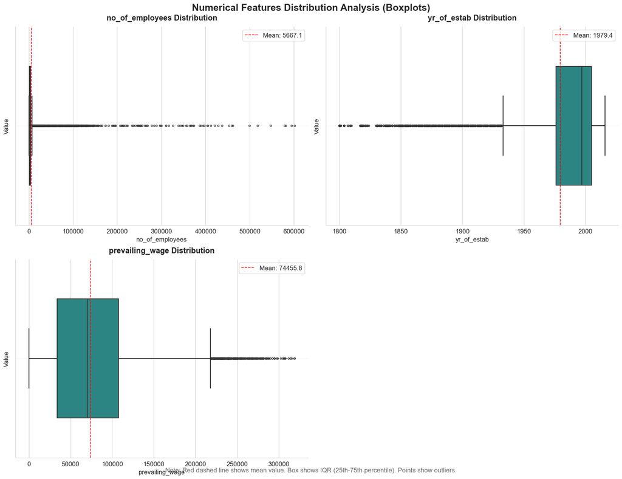

```python
# Plot boxplots for numerical variables
with warnings.catch_warnings():
    warnings.simplefilter("ignore")
    fig = plot_numerical_boxplots(data=df, numerical_features=column_numerical)
    plt.show()
```

### Univariate Analysis Observations (Numerical Variables)

#### Number of employees

- The number of employees has a range between 11 and 602,069 employees.
- Companies have a mean of 5667 employees, the median is 2,109 employees and it has a high standar deviation of 22,878 which indicates that some big outliers are pulling the mean.
- 25th Percentile: 1,022 employees.
- 75th Percentile: 3,504 employees.
- This variable is right skewed. Most companies are small to medium sized. But there are some large companies and outliers.
- The distribution peak near small companies (less than 1,000 employes) and then it has a sharp drop. Some large corporations produce a heavy tail.

#### Year of Establishment

- The range is between 1800 and 2016. Meaning that the oldest company was established in 1800 and the newest in 2016.
- The average establishment year is 1979, with a standard deviation of 42 years.
- 25th Percentile: 1976, 25% of the companies were established before 1976.
- 50th Percentile (Median): 1997, the median has 18 years diference with the mean.
- 75th Percentile: 2005, 75% of the companies were stablished before 2005.
- This variable is left skewed, most companies were stablished after 1976, but some older companies are pull the mean.

### Categorical Variables Frequencies

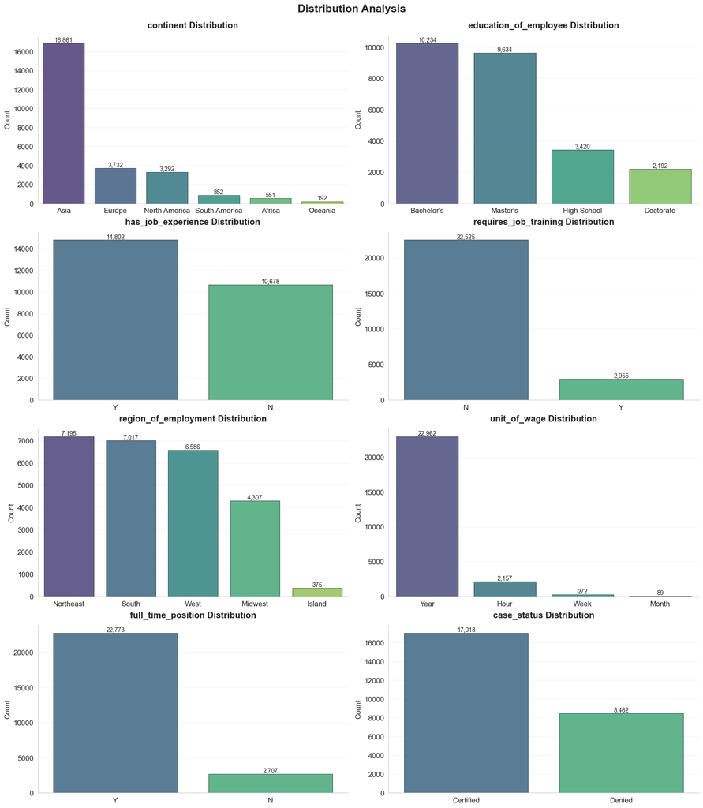

```python
# Barplots for categorical variables
column_categorical = ['continent', 'education_of_employee', 'has_job_experience', 'requires_job_training', 'region_of_employment', 'unit_of_wage', 'full_time_position', 'case_status']

with warnings.catch_warnings():
    warnings.simplefilter("ignore")
    fig = plot_categorical_distributions(df, column_categorical)
    plt.show()
```

## Bivariate Analysis

### Relationship Analysis

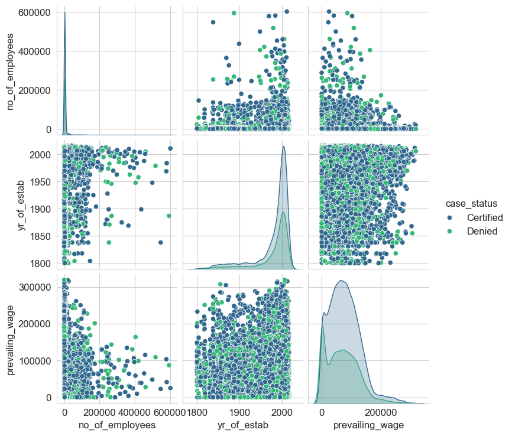

```python
# Understand the distribution of the numerical data.
sns.pairplot(df, hue="case_status", diag_kind="kde", palette="viridis", height=2.5)
plt.show()
```

- There are no clear linear relationships between the numerical variables.

### Correlation

```python
# Generate the correlation Matrix
df.corr(numeric_only=True)
```

|  | no_of_employees | yr_of_estab | prevailing_wage |
| --- | --- | --- | --- |
| no_of_employees | 1.000000 | -0.017770 | -0.009523 |
| yr_of_estab | -0.017770 | 1.000000 | 0.012342 |
| prevailing_wage | -0.009523 | 0.012342 | 1.000000 |

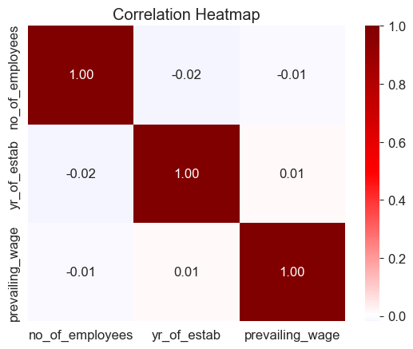

```python
# Plot the correlation matrix
sns.heatmap(df.corr(numeric_only=True), annot=True, cmap="seismic", center=0, fmt=".2f")
plt.title("Correlation Heatmap")
plt.show()
```

- As seen in the scatterplots, there is no correlation between the numerical variables.

### Bivariate Analysis Observations (Dependent Variable: Case Status)

Analyzing how categorical and numerical features interact with **Case Status**.

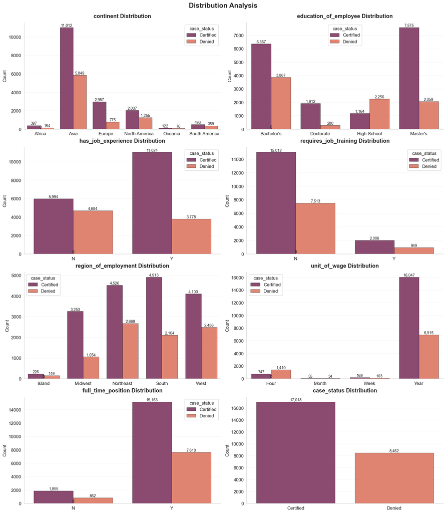

```python
# Plot the frequency of Case Status vs categorical variables
fig = plot_categorical_distributions(df, column_categorical, hue="case_status", palette="rocket")
with warnings.catch_warnings():
    warnings.simplefilter("ignore")
    plt.show();
```

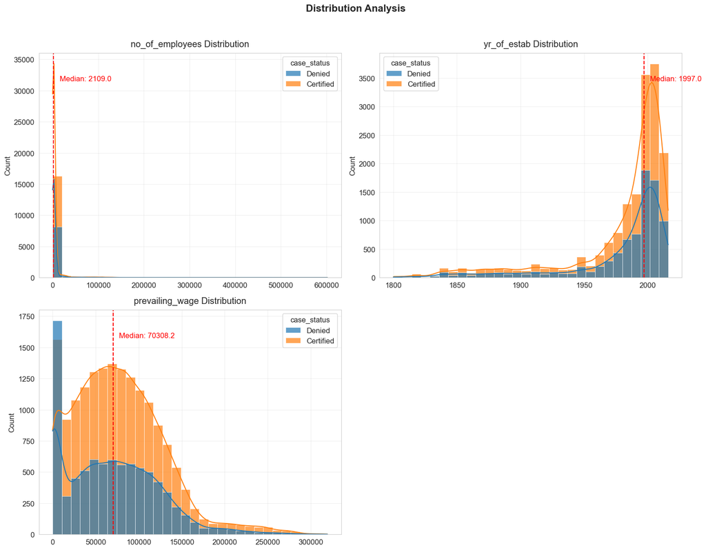

```python
# Plot the distribution of Personal Loan vs numerical variables
custom_palette = ['#33FF57','#5733FF','#FF5733']
fig = plot_numerical_distributions(data, column_numerical, hue="case_status", palette="tab10")
```

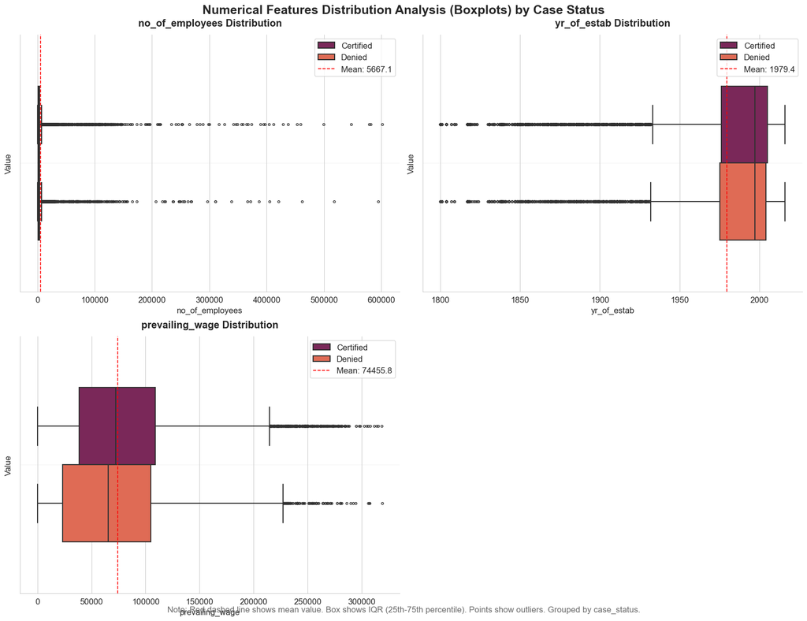

```python
# Plot boxplots for numerical variables
fig = plot_numerical_boxplots(data=df, numerical_features=column_numerical, hue="case_status", palette="rocket");
plt.suptitle('Numerical Features Distribution Analysis (Boxplots) by Case Status', fontsize=18, fontweight='bold', y=1.02)
plt.show()
```

### Bivariate Analysis Observations (Numerical Variables vs Case Status)

#### Number of Employees vs Case Status

- Companies with fewer employees have a higher rate of certification. The concentration of Certified cases is heaviest in firms with small to medium workforce sizes.

#### Year of Establishment vs. Case Status

- Companies established between 1900 and 2000 dominate Certified cases.
- Companies stablished after 2000, have a more mixed case outcome.

### Bivariate Analysis Observations (Categorical Variables vs Case Status)

#### Education Level vs Case Status

- Master’s and Doctorate degrees see higher certification rates, indicating a possible preference for applicants with advanced education.
- High School education shows more Denied cases than Certified, suggesting lower approval chances for less-educated applicants.
- Bachelor’s degrees have a substantial number of both Certified and Denied cases, but Certification remains dominant.

#### Job Experience vs Case Status

- Applicants with job experience have significantly more Certified cases, indicating that prior experience may boost approval chances.
- Applicants without experience show a more balanced distribution, meaning a lack of experience may contribute to increased denials.

#### Wage Unit vs. Case Status

- Yearly wage earners are certified the most—suggesting annual salary structures may influence positive case outcomes.
- Hourly wage applicants see a higher rate of Denied cases, indicating a potential disadvantage for workers paid by the hour.

#### Full-time vs. Case Status

- Full Time positions are certified 66%.
- Non-full-time positions are certified 68%
- There seems that there is the same probability to be certified for Full time and part time positions.

### Questions

**1 - Those with higher education may want to travel abroad for a well-paid job. Let's find out if education has any impact on visa certification.**

```python
# Percentage of Case Status by Education of Employee
df.groupby("education_of_employee")["case_status"].value_counts(normalize=True).unstack()
```

| case_status education_of_employee | Certified | Denied |
| --- | --- | --- |
| Bachelor's | 0.622142 | 0.377858 |
| Doctorate | 0.872263 | 0.127737 |
| High School | 0.340351 | 0.659649 |
| Master's | 0.786278 | 0.213722 |

- Visa applicants with higher educational credentials, such as those holding Master’s or Doctorate degrees, tend to have higher certification rates.

**2 - Lets' similarly check for the continents and find out how the visa status vary across different continents.**

```python
# Percentage of Case Status by Continent
df.groupby("continent")["case_status"].value_counts(normalize=True).unstack()
```

| case_status continent | Certified | Denied |
| --- | --- | --- |
| Africa | 0.720508 | 0.279492 |
| Asia | 0.653105 | 0.346895 |
| Europe | 0.792337 | 0.207663 |
| North America | 0.618773 | 0.381227 |
| Oceania | 0.635417 | 0.364583 |
| South America | 0.578638 | 0.421362 |

- Europe applicants have a 79% certified cases. Most likeley to be certified
- Africa applicants have a 72% certified cases. Second most likely to be certified.
- Asia and Oceania ha aproximately 65% certified cases.
- North and South America applicants ares les likely to be certified.

**3 - Experienced professionals might look abroad for opportunities to improve their lifestyles and career development. Let's see if having work experience has any influence over visa certification**

```python
# Percentage of Case Status by Job Experience
df.groupby("has_job_experience")["case_status"].value_counts(normalize=True).unstack()
```

| case_status has_job_experience | Certified | Denied |
| --- | --- | --- |
| N | 0.561341 | 0.438659 |
| Y | 0.744764 | 0.255236 |

- Applicants that have job experience are more likely to be certified with 74.47%
- Applicants with no job experience have 56% of certified cases. It is more balanced.

**4 - Checking if the prevailing wage is similar across all the regions of the US**

```python
# Average prevailing wage by region of employment
df.groupby("region_of_employment").mean(numeric_only=True)["prevailing_wage"].sort_values(ascending=False)
```

```
region_of_employment
Island       91712.750760
Midwest      91696.741794
South        74040.545216
West         69832.628698
Northeast    67872.662819
Name: prevailing_wage, dtype: float64
```

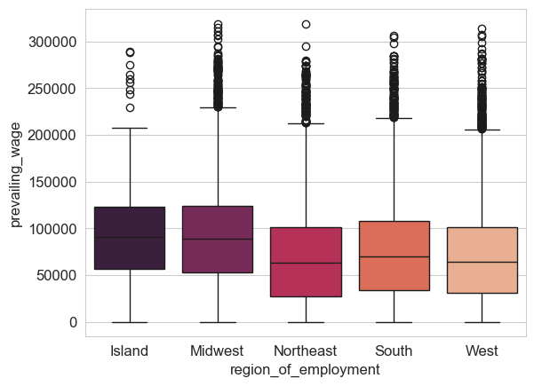

```python
# Boxplot of prevailing wage by region of employment
sns.boxplot(data=df, x="region_of_employment", y="prevailing_wage", palette="rocket")
plt.show()
```

- Island and Midwest have the higher prevailing wages averages and distributions. Midwest has more outliers.
- South has slightly higher prevailing wage than Northeast and West.
- Northeast has the lowest average prevailing wage.

**5 - The US government has established a prevailing wage to protect local talent and foreign workers. Let's analyze the data and see if the visa status changes with the prevailing wage**

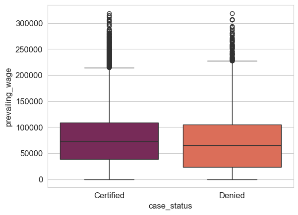

```python
# boxplot of prevailing wage by case status
sns.boxplot(data=df, x="case_status", y="prevailing_wage", palette="rocket")
plt.show()
```

- Certified cases have a slightly higher prevailing wage. the median prevailing wage for certified and denied cases are very close, but still higher for certified cases.

**6 - The prevailing wage has different units (Hourly, Weekly, etc). Let's find out if it has any impact on visa applications getting certified.**

```python
# Percentage of Case Status by Unit of Wage
df.groupby("unit_of_wage")["case_status"].value_counts(normalize=True).unstack()
```

| case_status unit_of_wage | Certified | Denied |
| --- | --- | --- |
| Hour | 0.346314 | 0.653686 |
| Month | 0.617978 | 0.382022 |
| Week | 0.621324 | 0.378676 |
| Year | 0.698850 | 0.301150 |

- Yearly unit of wage is most likely to be certified with 70% of certified cases.
- Hourly unit of wage is the most likeley to be denied with only 34.63% of certified cases.
- Monthly and weekly unit of wage is more balance with 62% of certified cases.

# 6 - Data Pre-processing

## Outlier Check

```python
results = []
for col in column_numerical:
    # Calculate Q1 (25th percentile) and Q3 (75th percentile)
    Q1 = data[col].quantile(0.25)
    Q3 = data[col].quantile(0.75)

    # Calculate IQR
    IQR = Q3 - Q1

    # Determine lower and upper bounds
    lower_bound = Q1 - 1.5 * IQR
    upper_bound = Q3 + 1.5 * IQR

    # Identify outliers
    outliers = data[(data[col] < lower_bound) | (data[col] > upper_bound)]

    # Store results
    results.append({
        'Column': col,
        'Lower Bound': lower_bound,
        'Upper Bound': upper_bound,
        'Outlier Count': len(outliers),
        'Outlier Percentage (%)': (len(outliers) / len(data)) * 100,
    })

outlier_df = pd.DataFrame(results)
outlier_df
```

|  | Column | Lower Bound | Upper Bound | Outlier Count | Outlier Percentage (%) |
| --- | --- | --- | --- | --- | --- |
| 0 | no_of_employees | -2701.00000 | 7227.00000 | 1556 | 6.106750 |
| 1 | yr_of_estab | 1932.50000 | 2048.50000 | 3260 | 12.794349 |
| 2 | prevailing_wage | -76564.56875 | 218315.56125 | 427 | 1.675824 |

- There are outliers in the numeric variables.
- Year of establishment is the variable with the highest percentage of outliers. This is because there are some historic companies that were stablished in the 1800s.
- Number of employees has a 6.10% percentage of outliers. This is because there are some large corporations.
- Prevailing Wage has a 1.68% percentage of outliers. THis is because some wages are express in hours, weeks, months and year.

The outliers are correct values. There is no need to treat outliers as there seems to be no errors.

## Data Preparation for modeling

```python
# Map case_status to 0 for denied and 1 to certified.
df["case_status"] = df["case_status"].str.strip().str.lower().map({"certified": 1, "denied": 0})
df.head()
```

|  | continent | education_of_employee | has_job_experience | requires_job_training | no_of_employees | yr_of_estab | region_of_employment | prevailing_wage | unit_of_wage | full_time_position | case_status |
| --- | --- | --- | --- | --- | --- | --- | --- | --- | --- | --- | --- |
| 0 | Asia | High School | N | N | 14513 | 2007 | West | 592.2029 | Hour | Y | 0 |
| 1 | Asia | Master's | Y | N | 2412 | 2002 | Northeast | 83425.6500 | Year | Y | 1 |
| 2 | Asia | Bachelor's | N | Y | 44444 | 2008 | West | 122996.8600 | Year | Y | 0 |
| 3 | Asia | Bachelor's | N | N | 98 | 1897 | West | 83434.0300 | Year | Y | 0 |
| 4 | Africa | Master's | Y | N | 1082 | 2005 | South | 149907.3900 | Year | Y | 1 |

```python
# Define Independent (X) and Dependent (y) variables
X = df.drop(["case_status"], axis=1)
y = df["case_status"]
```

```python
# Encode Categorical variables
X = pd.get_dummies(X, drop_first=True)
X.head()
```

|  | no_of_employees | yr_of_estab | prevailing_wage | continent_Asia | continent_Europe | continent_North America | continent_Oceania | continent_South America | education_of_employee_Doctorate | education_of_employee_High School | ... | has_job_experience_Y | requires_job_training_Y | region_of_employment_Midwest | region_of_employment_Northeast | region_of_employment_South | region_of_employment_West | unit_of_wage_Month | unit_of_wage_Week | unit_of_wage_Year | full_time_position_Y |
| --- | --- | --- | --- | --- | --- | --- | --- | --- | --- | --- | --- | --- | --- | --- | --- | --- | --- | --- | --- | --- | --- |
| 0 | 14513 | 2007 | 592.2029 | True | False | False | False | False | False | True | ... | False | False | False | False | False | True | False | False | False | True |
| 1 | 2412 | 2002 | 83425.6500 | True | False | False | False | False | False | False | ... | True | False | False | True | False | False | False | False | True | True |
| 2 | 44444 | 2008 | 122996.8600 | True | False | False | False | False | False | False | ... | False | True | False | False | False | True | False | False | True | True |
| 3 | 98 | 1897 | 83434.0300 | True | False | False | False | False | False | False | ... | False | False | False | False | False | True | False | False | True | True |
| 4 | 1082 | 2005 | 149907.3900 | False | False | False | False | False | False | False | ... | True | False | False | False | True | False | False | False | True | True |

5 rows × 21 columns

```python
# Check variable types after encoding
X.info()
```

```
<class 'pandas.core.frame.DataFrame'>
RangeIndex: 25480 entries, 0 to 25479
Data columns (total 21 columns):
 #   Column                             Non-Null Count  Dtype
---  ------                             --------------  -----
 0   no_of_employees                    25480 non-null  int64
 1   yr_of_estab                        25480 non-null  int64
 2   prevailing_wage                    25480 non-null  float64
 3   continent_Asia                     25480 non-null  bool
 4   continent_Europe                   25480 non-null  bool
 5   continent_North America            25480 non-null  bool
 6   continent_Oceania                  25480 non-null  bool
 7   continent_South America            25480 non-null  bool
 8   education_of_employee_Doctorate    25480 non-null  bool
 9   education_of_employee_High School  25480 non-null  bool
 10  education_of_employee_Master's     25480 non-null  bool
 11  has_job_experience_Y               25480 non-null  bool
 12  requires_job_training_Y            25480 non-null  bool
 13  region_of_employment_Midwest       25480 non-null  bool
 14  region_of_employment_Northeast     25480 non-null  bool
 15  region_of_employment_South         25480 non-null  bool
 16  region_of_employment_West          25480 non-null  bool
 17  unit_of_wage_Month                 25480 non-null  bool
 18  unit_of_wage_Week                  25480 non-null  bool
 19  unit_of_wage_Year                  25480 non-null  bool
 20  full_time_position_Y               25480 non-null  bool
dtypes: bool(18), float64(1), int64(2)
memory usage: 1.0 MB
```

## Spliting data in Train, Validation and Test

```python
# Split 70% for train
X_train, X_temp, y_train, y_temp = train_test_split(X, y, test_size=0.3, random_state=RS, stratify=y)
# Split 15% for validation and 15% for testing
X_val, X_test, y_val, y_test = train_test_split(X_temp, y_temp, test_size=0.5, random_state=RS, stratify=y_temp)
```

- The data will be split 70% for Training, 15% for Validation and 15% for Testing

```python
print(f"Original Dataset Shape: {X.shape}")
print(f"Training Shape: {X_train.shape}, Percentage: {round((X_train.shape[0]/X.shape[0]) * 100, 2)}%")
print(f"Validation Shape: {X_val.shape}, Percentage: {round((X_val.shape[0]/X.shape[0]) * 100, 2)}%")
print(f"Testing Shape: {X_test.shape}, Percentage: {round((X_test.shape[0]/X.shape[0]) * 100, 2)}%")
print("="*80)
print("Percentage of classes in training set:")
print(y_train.value_counts(normalize=True))
print("Percentage of classes in validation set:")
print(y_val.value_counts(normalize=True))
print("Percentage of classes in test set:")
print(y_test.value_counts(normalize=True))
```

```
Original Dataset Shape: (25480, 21)
Training Shape: (17836, 21), Percentage: 70.0%
Validation Shape: (3822, 21), Percentage: 15.0%
Testing Shape: (3822, 21), Percentage: 15.0%
================================================================================
Percentage of classes in training set:
case_status
1    0.667919
0    0.332081
Name: proportion, dtype: float64
Percentage of classes in validation set:
case_status
1    0.667713
0    0.332287
Name: proportion, dtype: float64
Percentage of classes in test set:
case_status
1    0.667975
0    0.332025
Name: proportion, dtype: float64
```

Same class proportions for Train, Validation and Test data.

# 7 - Model Building

#### Functions for model evaluation

Function that return a dataframe with performance metrics (Accuracy, Recall, Precision and F1).

```python
# defining a function to compute different metrics to check performance of a classification model built using sklearn
def model_performance_classification(model, predictors, target):
    """
    Function to compute different metrics to check classification model performance

    model: classifier
    predictors: independent variables
    target: dependent variable
    """

    # predicting using the independent variables
    pred = model.predict(predictors)

    acc = accuracy_score(target, pred)  # to compute Accuracy
    recall = recall_score(target, pred)  # to compute Recall
    precision = precision_score(target, pred)  # to compute Precision
    f1 = f1_score(target, pred)  # to compute F1-score

    # creating a dataframe of metrics
    df_perf = pd.DataFrame(
        {"Accuracy": acc, "Recall": recall, "Precision": precision, "F1": f1,},
        index=[0],
    )

    return df_perf
```

Function that returns the Confussion Matrix

```python
def plot_confussion_matrix(model, predictors, target):
    """
    To plot the confusion_matrix with percentages

    model: classifier
    predictors: independent variables
    target: dependent variable
    """
    # Predict the target values using the provided model and predictors
    y_pred = model.predict(predictors)

    # Compute the confusion matrix comparing the true target values with the predicted values
    cm = confusion_matrix(target, y_pred)

    # Create labels for each cell in the confusion matrix with both count and percentage
    labels = np.asarray(
        [
            ["{0:0.0f}".format(item) + "\n{0:.2%}".format(item / cm.flatten().sum())]
            for item in cm.flatten()
        ]
    ).reshape(2, 2)    # reshaping to a matrix

    # Set the figure size for the plot
    plt.figure(figsize=(6, 4))

    # Plot the confusion matrix as a heatmap with the labels
    sns.heatmap(cm, annot=labels, fmt="")

    # Add a label to the y-axis
    plt.ylabel("True label")

    # Add a label to the x-axis
    plt.xlabel("Predicted label")
```

```python
def plot_confusion_matrices(models, predictors, target, title):
    """
    Plots confusion matrices for multiple models in a grid with 3 columns.

    Parameters:
    -----------
    models : list of tuples
        Each tuple is (model_name: str, model_object: classifier).
    predictors : pd.DataFrame or np.array
        Features (X_test or similar).
    target : pd.Series or np.array
        True labels (y_test or similar).
    """
    n_models = len(models)
    n_cols = 3
    n_rows = math.ceil(n_models / n_cols)  # Dynamic row calculation

    plt.figure(figsize=(6 * n_cols, 4 * n_rows))  # Scale figure size
    plt.suptitle(title, fontsize=18, fontweight='bold', y=1.02)

    for i, (name, model) in enumerate(models, 1):
        try:
            y_pred = model.predict(predictors)
            cm = confusion_matrix(target, y_pred)

            # Labels with counts + percentages
            labels = np.asarray(
                [[f"{item}\n{item/cm.sum():.2%}"] for item in cm.flatten()]
            ).reshape(2, 2)

            plt.subplot(n_rows, n_cols, i)
            sns.heatmap(cm, annot=labels, fmt="", cmap="Blues", cbar=False)
            plt.title(name)
            plt.ylabel("True label")
            plt.xlabel("Predicted label")

        except AttributeError:
            print(f"'{name}': Not a valid model.")
            continue

    plt.tight_layout()
    plt.show()
```

## Model Evaluation Criterion

#### Defining scorer to be used for cross-validation and hyperparameter tuning

**False Positives and False Negatives Are Equally Costly.**

Both false positives and false negatives are highly costly in the certification process, and addressing either error is crucial:

- False Positives: These occur when an applicant is predicted as Certified when, in reality, they should be Denied. This misclassification results in wasted time and resources throughout the application process. Moreover, it carries an opportunity cost by potentially displacing local talent or more qualified candidates, thereby depriving the workforce of their rightful contributions.
- False Negatives: These occur when an applicant is predicted as Denied when they should be Certified. The consequence is the wrongful rejection of legitimate applicants, leading to unjust outcomes. Additionally, this error means the economy loses out on skilled labor, as candidates who could provide significant value to the workforce are not admitted.

The F1-score’s balance of precision (minimizing false positives) and recall (minimizing false negatives) ensures neither error disproportionately harms applicants or the labor market.

```python
# Define F1 scorer for model evaluation
scorer = metrics.make_scorer(metrics.f1_score)
```

**We are now done with pre-processing and evaluation criterion, so let's start building the model.**

## Model building with original data

```python
models = []  # Empty list to store all the models

# Appending models into the list
models.append(("Decision Tree", DecisionTreeClassifier(random_state=RS)))
models.append(("Random Forest", RandomForestClassifier(random_state=RS)))
models.append(("Bagging", BaggingClassifier(random_state=RS)))
models.append(("GBM", GradientBoostingClassifier(random_state=RS)))
models.append(("AdaBoost", AdaBoostClassifier(random_state=RS)))
models.append(("XGBoost", XGBClassifier(random_state=RS, eval_metric="logloss")))
```

```python
results = []  # Empty list to store all model's CV scores
names = []  # Empty list to store name of the models
scores = []
results_scores_training = []  # Empty list to store the scores of the models on training set
results_scores_validation = []  # Empty list to store the scores of the models on validation set

# loop through all models to get the mean cross validated score
print("\n" "Cross-Validation Performance:" "\n")
for name, model in models:
    scoring = "f1"
    kfold = StratifiedKFold(
        n_splits=5, shuffle=True, random_state=RS
    )  # Setting number of splits equal to 5
    cv_result = cross_val_score(
        estimator=model, X=X_train, y=y_train, scoring=scoring, cv=kfold
    )
    results.append(cv_result)
    names.append(name)

    print(f"{name}: {cv_result.mean()}")

print("\n" "Validation Performance:" "\n")

for name, model in models:
    model.fit(X_train, y_train)
    score = f1_score(y_val, model.predict(X_val))
    scores.append(score)
    print(f"{name}: {score}")
    results_scores_training.append(model_performance_classification(model, X_train, y_train))
    results_scores_validation.append(model_performance_classification(model, X_val, y_val))
```

```
Cross-Validation Performance:

Decision Tree: 0.7410652876513099
Random Forest: 0.8037837241749051
Bagging: 0.7756586246579394
GBM: 0.823039791269532
AdaBoost: 0.8203377989495703
XGBoost: 0.8095211182586954

Validation Performance:

Decision Tree: 0.74792572105887
Random Forest: 0.7969132316958404
Bagging: 0.7730133752950433
GBM: 0.8220679576178297
AdaBoost: 0.8175919250180245
XGBoost: 0.8074418604651162
```

#### Observations:

**Cross-Validation Performance:**

**Validation Set Performance:**

- Decision Tree performs slightly better on the Validation set, but still has the lowest performance.
- Random Forest and XGBoost perform slightly wort on the validation set.
- AdaBoost performs slightly wortst with a score of 0.8175
- GBM performs slightly wortst with a score of 0.822, bust still is has the highest performance.

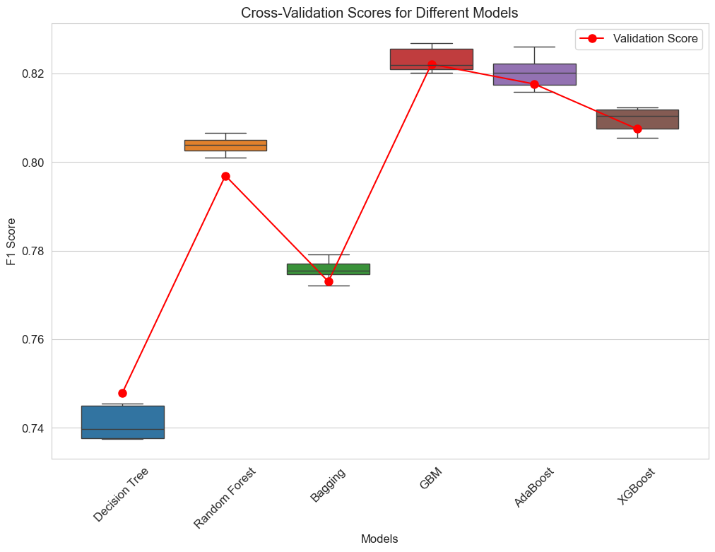

```python
# Plot the cross-validation scores for each model
plt.figure(figsize=(12, 8))
sns.boxplot(data=results)

# Add the validation scores on top of the boxplot
val_performance = scores
plt.plot(np.arange(len(names)), val_performance, marker="o", color="red", markersize=8, label="Validation Score")

plt.xticks(ticks=np.arange(len(names)), labels=names, rotation=45)
plt.title("Cross-Validation Scores for Different Models")
plt.xlabel("Models")
plt.ylabel("F1 Score")
plt.legend()
plt.show()
```

#### Observations:

- GBM has the highest Cross Validation scores and also has the highest score with the validation set.
- AdaBoost and XGBoost have good performance, but below GBM.
- Bagging and Decision Tree are the worst performers.

### Other Performance Metrics and Confusion Matrices

```python
# Print the training scores for each model
print("Training Performance:" "\n")
for name, score in zip(names, results_scores_training):
    print(f"{name} Training Scores:")
    print(score)
```

```
Training Performance:

Decision Tree Training Scores:
   Accuracy  Recall  Precision   F1
0       1.0     1.0        1.0  1.0
Random Forest Training Scores:
   Accuracy    Recall  Precision        F1
0  0.999944  0.999916        1.0  0.999958
Bagging Training Scores:
   Accuracy    Recall  Precision        F1
0  0.985198  0.985982    0.99181  0.988887
GBM Training Scores:
   Accuracy   Recall  Precision        F1
0  0.758802  0.88374   0.783042  0.830349
AdaBoost Training Scores:
   Accuracy   Recall  Precision        F1
0  0.739684  0.88735   0.762039  0.819934
XGBoost Training Scores:
   Accuracy    Recall  Precision        F1
0  0.841444  0.929825   0.847578  0.886798
```

```python
# Print the validation scores for each model
print("Validation Performance:" "\n")
for name, score in zip(names, results_scores_validation):
    print(f"{name} Validation Scores:")
    print(score)
```

```
Validation Performance:

Decision Tree Validation Scores:
   Accuracy    Recall  Precision        F1
0  0.666143  0.741771   0.754183  0.747926
Random Forest Validation Scores:
   Accuracy    Recall  Precision        F1
0  0.717687  0.829545   0.766751  0.796913
Bagging Validation Scores:
   Accuracy    Recall  Precision        F1
0  0.698064  0.769984   0.776066  0.773013
GBM Validation Scores:
   Accuracy    Recall  Precision        F1
0   0.74516  0.881661   0.770021  0.822068
AdaBoost Validation Scores:
   Accuracy    Recall  Precision        F1
0  0.735217  0.888715   0.757009  0.817592
XGBoost Validation Scores:
   Accuracy    Recall  Precision        F1
0  0.729199  0.850313   0.768686  0.807442
```

#### Observations on Other Performance Metrics:

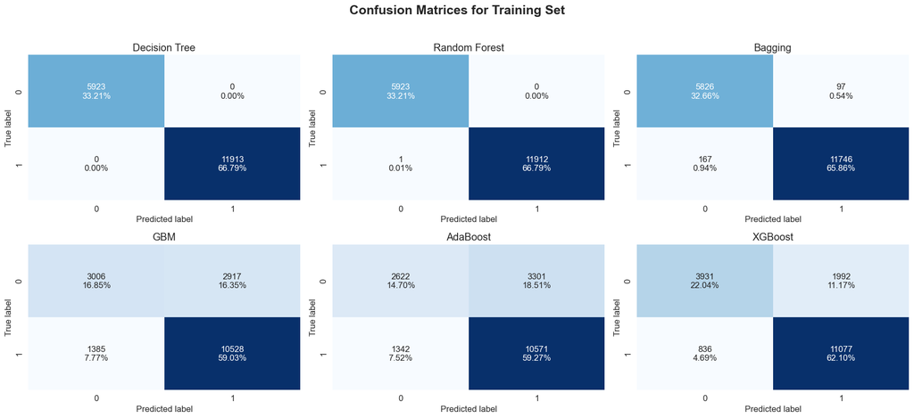

```python
# Plot confusion matrices for each model on the training set
plot_confusion_matrices(models, X_train, y_train, "Confusion Matrices for Training Set")
```

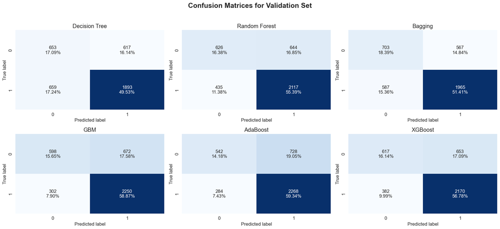

```python
# Plot confusion matrices for each model on the validation set
plot_confusion_matrices(models, X_val, y_val, "Confusion Matrices for Validation Set")
```

#### Observations:

- AdaBoost has the lowest percentage of False Negatives with 7.43%
- Bagging has the lowest percentage of False Positves with 14.84%
- GBM performs best overall. As it has a better performance with False Positives than Adaboost and is very similiar with False Negatives.

## Model Building with oversampled data

```python
# Check the class distribution in the training set
print("Class distribution in the training set:")
print(y_train.value_counts())
print("Shape of trianing set:", X_train.shape)
```

```
Class distribution in the training set:
case_status
1    11913
0     5923
Name: count, dtype: int64
Shape of trianing set: (17836, 21)
```

```python
# Fit SMOTE on train data
sm = SMOTE(sampling_strategy=1, k_neighbors=5, random_state=RS)
# Resample the training data
X_train_over, y_train_over = sm.fit_resample(X_train, y_train)
```

```python
# Check the class distribution in the training set
print("Class distribution in the training set after SMOTE:")
print(y_train_over.value_counts())
print("Shape of trianing set:", X_train_over.shape)
```

```
Class distribution in the training set after SMOTE:
case_status
1    11913
0    11913
Name: count, dtype: int64
Shape of trianing set: (23826, 21)
```

```python
models_over = []  # Empty list to store all the models

# Appending models into the list
models_over.append(("Decision Tree", DecisionTreeClassifier(random_state=RS)))
models_over.append(("Random Forest", RandomForestClassifier(random_state=RS)))
models_over.append(("Bagging", BaggingClassifier(random_state=RS)))
models_over.append(("GBM", GradientBoostingClassifier(random_state=RS)))
models_over.append(("AdaBoost", AdaBoostClassifier(random_state=RS)))
models_over.append(("XGBoost", XGBClassifier(random_state=RS, eval_metric="logloss")))
```

```python
results_over = []  # Empty list to store all model's CV scores
names_over = []  # Empty list to store name of the models
scores_over = []
results_scores_training_over = []  # Empty list to store the scores of the models
results_scores_validation_over = []  # Empty list to store the scores of the models on validation set

# loop through all models to get the mean cross validated score
print("\n" "Cross-Validation Performance - Oversampling:" "\n")
for name, model in models_over:
    scoring = "f1"
    kfold = StratifiedKFold(
        n_splits=5, shuffle=True, random_state=RS
    )  # Setting number of splits equal to 5
    cv_result = cross_val_score(
        estimator=model, X=X_train_over, y=y_train_over, scoring=scoring, cv=kfold
    )
    results_over.append(cv_result)
    names_over.append(name)
    print(f"{name}: {cv_result.mean()}")

print("\n" "Validation Performance - Oversampling:" "\n")

for name, model in models_over:
    model.fit(X_train_over, y_train_over)
    score = f1_score(y_val, model.predict(X_val))
    scores_over.append(score)
    print(f"{name}: {score}")
    results_scores_training_over.append(model_performance_classification(model, X_train_over, y_train_over))
    results_scores_validation_over.append(model_performance_classification(model, X_val, y_val))
```

```
Cross-Validation Performance - Oversampling:

Decision Tree: 0.7236479557474234
Random Forest: 0.7935193362866556
Bagging: 0.7553714301070087
GBM: 0.8076949280007495
AdaBoost: 0.8013161599972107
XGBoost: 0.799430071068073

Validation Performance - Oversampling:

Decision Tree: 0.7373878364905284
Random Forest: 0.7953638609158274
Bagging: 0.7623762376237624
GBM: 0.8132317413120238
AdaBoost: 0.8121827411167513
XGBoost: 0.8049235359940321
```

#### Observations:

**Cross-Validation Performance:**

- The decision tree model had the lowest score with 0.7236
- Bagging, Random Forest and XGBoost all had a score lower to 0.80
- GBM had the best score with 0.8076 followed by AdaBoost with 0.8013

**Validation Set Performance:**

- The decision tree has improved to 0.7373 with the validation set, but still is the worst performing model.
- Bagging and Random Forest also have a slight improvent on performance with the validation set, but are still below 0.80.
- XGBoost model improves to 0.8049 and is now above 0.80
- GBM and Adaboost also have slight improvements with validation set.
- GBM has the best perfomance with cross validation trainning and validation set.

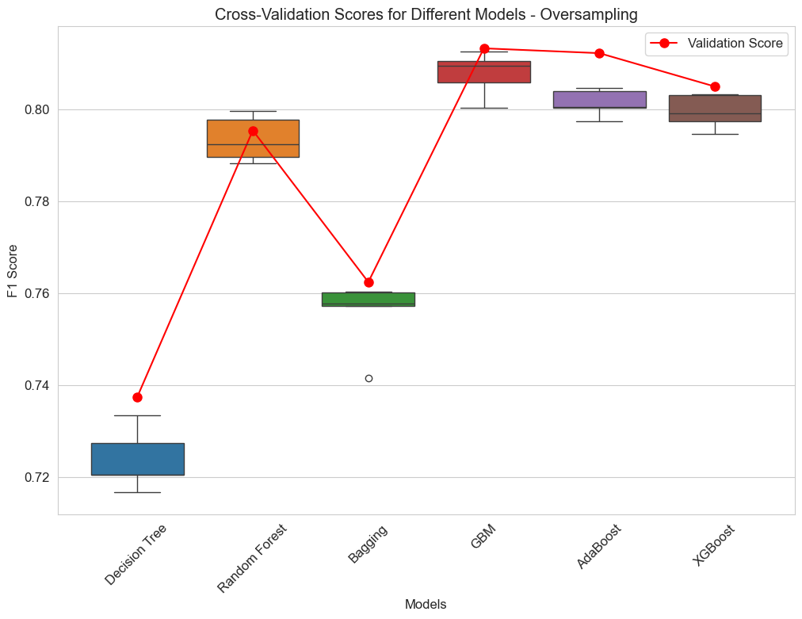

```python
plt.figure(figsize=(12, 8))
sns.boxplot(data=results_over)

val_performance = scores_over
plt.plot(np.arange(len(names)), val_performance, marker="o", color="red", markersize=8, label="Validation Score")

plt.xticks(ticks=np.arange(len(names)), labels=names, rotation=45)
plt.title("Cross-Validation Scores for Different Models - Oversampling")
plt.xlabel("Models")
plt.ylabel("F1 Score")
plt.legend()
plt.show()
```

#### Observations:

- GBM with Oversampled Data is the best performer has better Cross Validation scores.
- On the validation set score AdaBoost and GBM perform very good. GBM is slightly better.
- XGBoost with Oversampled data perfoms slightly worse than GBM and AdaBoost.
- Random Forest has good performance, but bellow XGBoost, AdaBoost and GBM.
- Bagging and Decision Tree are the woerst performers.

### Other Performance Metrics - Oversampling

```python
# Review other performance metrics for the trained models with oversampling.
for name, score in zip(names, results_scores_training_over):
    print(f"{name} Training Scores:")
    print(score)
```

```
Decision Tree Training Scores:
   Accuracy  Recall  Precision   F1
0       1.0     1.0        1.0  1.0
Random Forest Training Scores:
   Accuracy    Recall  Precision        F1
0  0.999958  0.999916        1.0  0.999958
Bagging Training Scores:
   Accuracy    Recall  Precision        F1
0  0.987451  0.982876   0.991952  0.987393
GBM Training Scores:
   Accuracy    Recall  Precision        F1
0  0.798413  0.864602   0.763529  0.810928
AdaBoost Training Scores:
   Accuracy    Recall  Precision        F1
0  0.782045  0.882985    0.73467  0.802028
XGBoost Training Scores:
   Accuracy    Recall  Precision       F1
0   0.86116  0.911945   0.827859  0.86787
```

```python
# Review other performance metrics for the models trained on oversampled data with the validation set.
for name, score in zip(names, results_scores_validation_over):
    print(f"{name} Validation Scores:")
    print(score)
```

```
Decision Tree Validation Scores:
   Accuracy   Recall  Precision        F1
0  0.655416  0.72453   0.750711  0.737388
Random Forest Validation Scores:
   Accuracy    Recall  Precision        F1
0   0.71821  0.820141    0.77204  0.795364
Bagging Validation Scores:
   Accuracy   Recall  Precision        F1
0  0.686028  0.75431   0.770616  0.762376
GBM Validation Scores:
   Accuracy    Recall  Precision        F1
0  0.737049  0.857367   0.773418  0.813232
AdaBoost Validation Scores:
   Accuracy    Recall  Precision        F1
0  0.728938  0.877743   0.755735  0.812183
XGBoost Validation Scores:
   Accuracy    Recall  Precision        F1
0  0.726321  0.845611   0.767972  0.804924
```

#### Observations on Other Performance Metrics - Oversampling:

- With the oversampled training set Decision Tree, Random Forest and Bagging have perfect scores or near perfet. Meaning that this models are clearly overfitting.
- GBM, AdaBoost and XGBoost have a much better Accuracy Scores than Decision Tree, Random Forest and Bagging with the validation test.
- GBM has a 0.7370 Accuracy Score on Validation test and is the best Accuracy Score.
- Ada boost has a 0.8777 Recall Score and is the best Recall Score.
- GBM has a 0.7734 Precision Score and is the best Precision Score. Random Forest and Bagging had also the highest Precision Scores after GBM.
- GBM has a 0.8132 F1-Score and the best F1-Score.
- GBM is the model with the best scores in 3 performance metrics (Accuracy, Precision and F1)

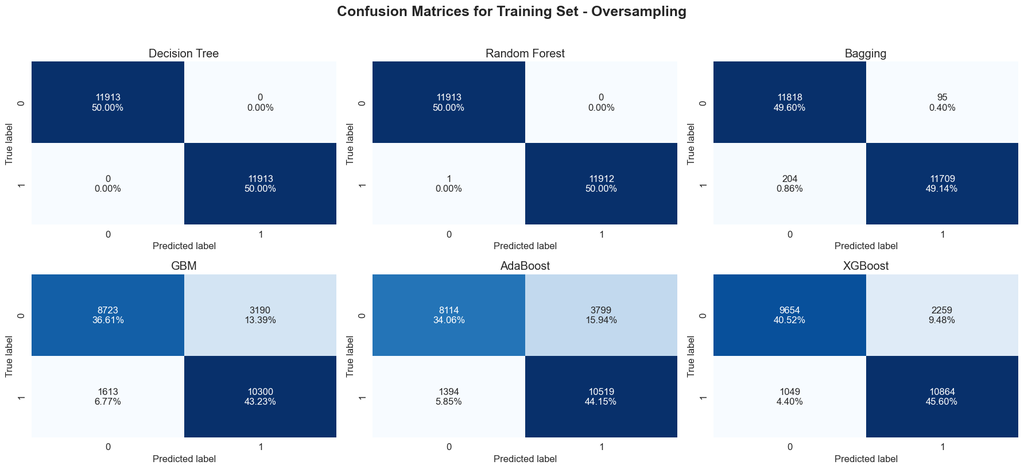

```python
plot_confusion_matrices(models_over, X_train_over, y_train_over, "Confusion Matrices for Training Set - Oversampling")
```

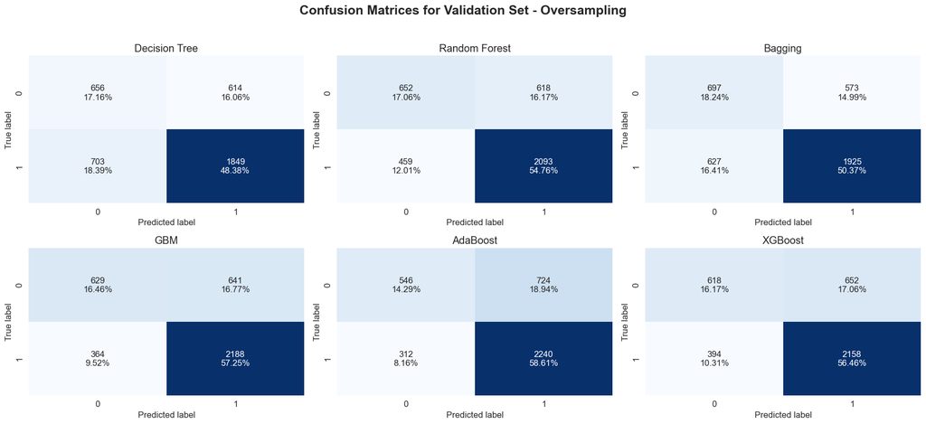

```python
plot_confusion_matrices(models_over, X_val, y_val, "Confusion Matrices for Validation Set - Oversampling")
```

#### Observations:

- AdaBoost has the lowest percentage of False Negatives with 8.16%
- Bagging has the lowest False Positives with 14.99%
- GBM overall has the better perfomance of the models with oversampled data.

## Model Building with undersampled data

```python
# Check the class distribution in the training set
print("Class distribution in the training set:")
print(y_train.value_counts())
print("Shape of trianing set:", X_train.shape)
```

```
Class distribution in the training set:
case_status
1    11913
0     5923
Name: count, dtype: int64
Shape of trianing set: (17836, 21)
```

```python
random_under = RandomUnderSampler(sampling_strategy=1, random_state=RS)
# Resample the training data
X_train_under, y_train_under = random_under.fit_resample(X_train, y_train)
# Check the class distribution in the training set
print("Class distribution in the training set after Random Under Sampling:")
print(y_train_under.value_counts())
print("Shape of trianing set:", X_train_under.shape)
```

```
Class distribution in the training set after Random Under Sampling:
case_status
0    5923
1    5923
Name: count, dtype: int64
Shape of trianing set: (11846, 21)
```

```python
models_under = []  # Empty list to store all the models

# Appending models into the list
models_under.append(("Decision Tree", DecisionTreeClassifier(random_state=RS)))
models_under.append(("Random Forest", RandomForestClassifier(random_state=RS)))
models_under.append(("Bagging", BaggingClassifier(random_state=RS)))
models_under.append(("GBM", GradientBoostingClassifier(random_state=RS)))
models_under.append(("AdaBoost", AdaBoostClassifier(random_state=RS)))
models_under.append(("XGBoost", XGBClassifier(random_state=RS, eval_metric="logloss")))
```

```python
results_under = []  # Empty list to store all model's CV scores
names_under = []  # Empty list to store name of the models
scores_under = []
results_scores_training_under = []  # Empty list to store the scores of the models
results_scores_validation_under = []  # Empty list to store the scores of the models on validation set

# loop through all models to get the mean cross validated score
print("\n" "Cross-Validation Performance:" "\n")
for name, model in models_under:
    scoring = "f1"
    kfold = StratifiedKFold(
        n_splits=5, shuffle=True, random_state=RS
    )  # Setting number of splits equal to 5
    cv_result = cross_val_score(
        estimator=model, X=X_train_under, y=y_train_under, scoring=scoring, cv=kfold
    )
    results_under.append(cv_result)
    names_under.append(name)
    print(f"{name}: {cv_result.mean()}")

print("\n" "Validation Performance:" "\n")

for name, model in models_under:
    model.fit(X_train_under, y_train_under)
    score = f1_score(y_val, model.predict(X_val))
    scores_under.append(score)
    print(f"{name}: {score}")
    results_scores_training_under.append(model_performance_classification(model, X_train_under, y_train_under))
    results_scores_validation_under.append(model_performance_classification(model, X_val, y_val))
```

```
Cross-Validation Performance:

Decision Tree: 0.617022679979161
Random Forest: 0.6875011408129813
Bagging: 0.6411413525524321
GBM: 0.7131358906535971
AdaBoost: 0.6949405744215158
XGBoost: 0.6944693136408734

Validation Performance:

Decision Tree: 0.6819360414866033
Random Forest: 0.7322615219721329
Bagging: 0.6928221132411948
GBM: 0.7641014887817152
AdaBoost: 0.7638544251447478
XGBoost: 0.7472064094454987
```

#### Observations:

**Cross-Validation Performance:**

- GBM is the best performer with an average score of 0.7131
- AdaBoost and XGBoost have average scores of 0.69
- Random Forest is very closley to AdaBoost and XGBoost with 0.6875
- Decision Tree and Bagging have the worst average scores.
- All of the models perform worts than the Oversample and Original sets.

**Validation Perfomance:**

- GBM is the best performer with a score of 0.7641, and performs better than the trainning cross validation.
- AdaBoost and XGBoost also perform better with the validation set than the training set.
- Random Forest gets a 0.7322 score on the validation set. Bagging and Decision Tree remain the worst performers.
- All the model perform worst than the models with oversample data.

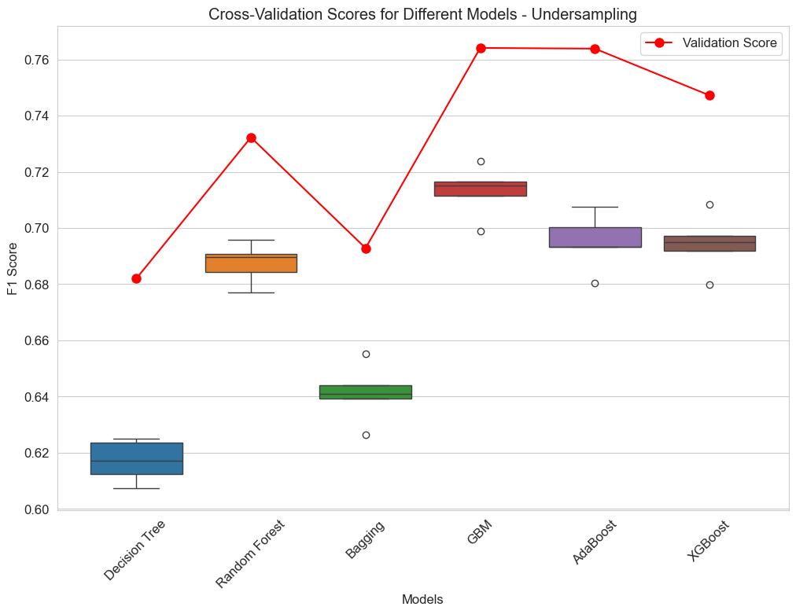

```python
plt.figure(figsize=(12, 8))
sns.boxplot(data=results_under)

val_performance = scores_under
plt.plot(np.arange(len(names)), val_performance, marker="o", color="red", markersize=8, label="Validation Score")

plt.xticks(ticks=np.arange(len(names)), labels=names, rotation=45)
plt.title("Cross-Validation Scores for Different Models - Undersampling")
plt.xlabel("Models")
plt.ylabel("F1 Score")
plt.legend()
plt.show()
```

#### Observations:

- All the models perform better with the validation set than with the cross-validation training set.
- GBM is the model with the best scores and is the only model to have an average score above 0.70 in the cross-validation.
- AdaBoost and XGBoost have similar average scores around 0.69, but XGBoost was a lower validation set score than AdaBoost and GBM.
- All the Undersample Models perform worst than the Oversample Models.

### Other Performance Metrics - Undersampling

```python
for name, score in zip(names, results_scores_training_under):
    print(f"{name} Training Scores:")
    print(score)
```

```
Decision Tree Training Scores:
   Accuracy  Recall  Precision   F1
0       1.0     1.0        1.0  1.0
Random Forest Training Scores:
   Accuracy  Recall  Precision   F1
0       1.0     1.0        1.0  1.0
Bagging Training Scores:
   Accuracy    Recall  Precision        F1
0  0.980415  0.969272   0.991366  0.980195
GBM Training Scores:
   Accuracy    Recall  Precision        F1
0   0.72286  0.729529   0.719927  0.724696
AdaBoost Training Scores:
   Accuracy  Recall  Precision        F1
0  0.694918  0.7221   0.684868  0.702991
XGBoost Training Scores:
   Accuracy    Recall  Precision        F1
0  0.855732  0.859699   0.852931  0.856302
```

```python
for name, score in zip(names, results_scores_validation_under):
    print(f"{name} Validation Scores:")
    print(score)
```

```
Decision Tree Validation Scores:
   Accuracy    Recall  Precision        F1
0  0.614861  0.618339   0.760116  0.681936
Random Forest Validation Scores:
   Accuracy    Recall  Precision        F1
0  0.673208  0.669279   0.808329  0.732262
Bagging Validation Scores:
   Accuracy    Recall  Precision        F1
0  0.639456  0.608934   0.803516  0.692822
GBM Validation Scores:
   Accuracy   Recall  Precision        F1
0  0.705651  0.71395   0.821831  0.764101
AdaBoost Validation Scores:
   Accuracy    Recall  Precision        F1
0  0.701204  0.723746   0.808669  0.763854
XGBoost Validation Scores:
   Accuracy    Recall  Precision        F1
0   0.68629  0.694357   0.808763  0.747206
```

#### Observations:

- Decsion Tree, Random Forest and Bagging are overfitting the undersample data. As they achieve perfect or almost perfect scores with the undersample training data, but performance decreses dramatically with the validation set.
- XGBoost is also overfitting, as it has performance scores above 0.85 in the undersample training set, but the validation set scores perform much worst.
- GBM and Adaboost are generalizing much better as their scores are more similar in training and validation.
- GBM is the best performer of all the models with undersample data.

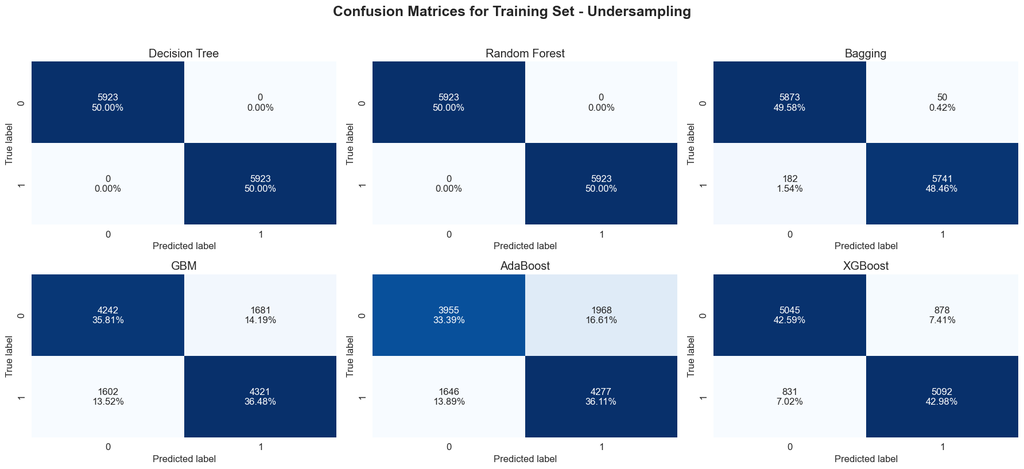

```python
plot_confusion_matrices(models_under, X_train_under, y_train_under, "Confusion Matrices for Training Set - Undersampling")
```

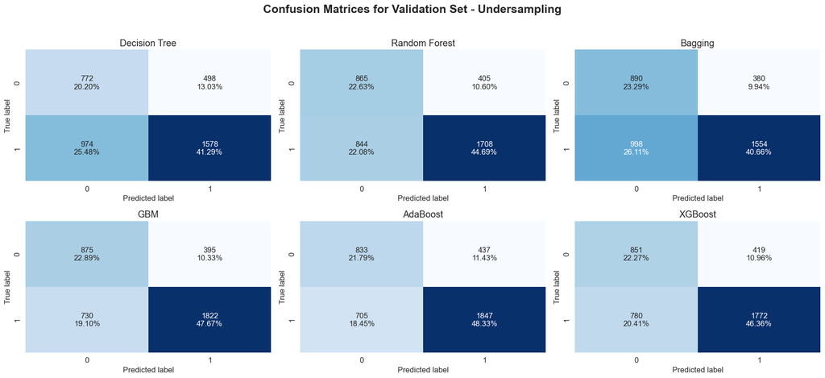

```python
plot_confusion_matrices(models_under, X_val, y_val, "Confusion Matrices for Validation Set - Undersampling")
```

#### Observations:

- All the models are having problems with False Negatives.
- AdaBoost has 18.45% of False Negatives. And is model with the samllest percentage of False Negatives.
- Bagging has 9.94% of False Positives, and is the model with the samllest percentage of False Positives.
- GBM and AdaBoost are the models that are more balance with incorrect False Positives and False negatives.

### Models with best performance

Decision Tree, Random Forest and Bagging have the worst scores with the original, oversample and undersample data. So this models are discarded for Hyper-parameter tuning.

All the models using undersampled data have a significant decrease in perfomance. So the undersample data will not be used for Hyper-parameter tuning.

The models that have the best performance (Highest F1 Score) are:

- GBM with Original Data Cross-Val(0.8230), Validation Set(0.822)
- AdaBoost with Original Data Cross-Val(0.8203), Validation Set(0.8175)
- GBM with Oversample Data Cross-Val(0.8076), Validation Set(0.8132)
- AdaBoost with Oversample Data Cross-Val(0.8013), Validation Set(0.8121)

The best XGBoost model is the one that uses the original data. With Oversample there is a slight decrease in performance.

- XGBoost with Original Data Cross-Val(0.8095), Validation Set( 0.8074)

The best Undersample model is GBM:

- GBM with undersample Data Cross-Val(0.7131), Validation Set(0.7641)

Overall GBM and AdaBoost are the best model with the original, oversample and undersample data. The best XGBoost and the best Undersample model will be added for Hyper-Parameter Tuning.

## Hyperparameter Tuning

### GBM with Oversampled Data - Tuning

```python
%%time
# Hyperparameter tuning for Gradient Boosting Classifier using RandomizedSearchCV
# Define the parameter grid for Gradient Boosting Classifier
param_grid = {
    # Core parameters
    'n_estimators': np.arange(50, 500, 50),
    'learning_rate': [0.001, 0.01, 0.05, 0.1, 0.2],
    'max_depth': np.arange(3, 11),
    'min_samples_split': np.arange(2, 21),
    'min_samples_leaf': np.arange(1, 21),

    # Stochastic gradient boosting (reduces overfitting)
    'subsample': [0.5, 0.7, 0.9, 1.0],

    # Regularization
    'max_features': ['sqrt', 'log2', None],
    'loss': ['log_loss', 'exponential'],
}

# Initialize the Gradient Boosting Classifier
gbm_over = GradientBoostingClassifier(random_state=RS)

# Perform Randomized Search with cross-validation
search_gbm_over = RandomizedSearchCV(
    estimator=gbm_over,
    param_distributions=param_grid,
    n_iter=50,
    cv=5,
    scoring='f1',
    n_jobs=-1,
    random_state=RS
)

# Fit the model on the oversampled training data
search_gbm_over.fit(X_train_over, y_train_over)
print("Best parameters found: ", search_gbm_over.best_params_)
print("Best F1 score: ", search_gbm_over.best_score_)
```

```
Best parameters found:  {'subsample': 1.0, 'n_estimators': np.int64(250), 'min_samples_split': np.int64(15), 'min_samples_leaf': np.int64(13), 'max_features': 'log2', 'max_depth': np.int64(9), 'loss': 'log_loss', 'learning_rate': 0.01}
Best F1 score:  0.8033582034494071
CPU times: user 6.76 s, sys: 1.09 s, total: 7.85 s
Wall time: 2min 23s
```

```python
# Tuned Gradient Boosting Classifier with the best parameters
gbm_over_tuned = GradientBoostingClassifier(
    subsample=1.0,
    n_estimators=250,
    min_samples_split=15,
    min_samples_leaf=13,
    max_features="log2",
    max_depth=9,
    loss="log_loss",
    learning_rate=0.01,
    random_state=RS
    )
# Fit the tuned model on the oversampled training data
gbm_over_tuned.fit(X_train_over, y_train_over)
```

```
GradientBoostingClassifier(learning_rate=0.01, max_depth=9, max_features='log2',
                           min_samples_leaf=13, min_samples_split=15,
                           n_estimators=250, random_state=1)
```

```python
#GBM performance on the Oversample training set
gbm_over_training_performance = model_performance_classification(gbm_over_tuned, X_train_over, y_train_over)
gbm_over_training_performance
```

|  | Accuracy | Recall | Precision | F1 |
| --- | --- | --- | --- | --- |
| 0 | 0.810543 | 0.868295 | 0.778388 | 0.820887 |

```python
#GBM performance on the validation set
gbm_over_validation_performance = model_performance_classification(gbm_over_tuned, X_val, y_val)
gbm_over_validation_performance
```

|  | Accuracy | Recall | Precision | F1 |
| --- | --- | --- | --- | --- |
| 0 | 0.740973 | 0.853056 | 0.779728 | 0.814746 |

### GBM with Original Data - Tuning

```python
%%time
# Hyperparameter tuning for Gradient Boosting Classifier using RandomizedSearchCV
# Define the parameter grid for Gradient Boosting Classifier
param_grid = {
    # Core parameters
    'n_estimators': np.arange(50, 500, 50),
    'learning_rate': [0.001, 0.01, 0.05, 0.1, 0.2],
    'max_depth': np.arange(3, 11),
    'min_samples_split': np.arange(2, 21),
    'min_samples_leaf': np.arange(1, 21),

    # Stochastic gradient boosting (reduces overfitting)
    'subsample': [0.5, 0.7, 0.9, 1.0],

    # Regularization
    'max_features': ['sqrt', 'log2', None],
    'loss': ['log_loss', 'exponential'],
}

# Initialize the Gradient Boosting Classifier
gbm_original = GradientBoostingClassifier(random_state=RS)

# Perform Randomized Search with cross-validation
search_gbm_original = RandomizedSearchCV(
    estimator=gbm_original,
    param_distributions=param_grid,
    n_iter=50,                  # Number of parameter combinations to try
    cv=5,                       # 5-fold cross-validation
    scoring='f1',          # Use 'neg_mean_squared_error' for regression
    n_jobs=-1,                  # Use all CPU cores
    random_state=RS
)
# Fit the model with the training data
search_gbm_original.fit(X_train, y_train)
print("Best parameters found: ", search_gbm_original.best_params_)
print("Best F1 score: ", search_gbm_original.best_score_)
```

```
Best parameters found:  {'subsample': 0.9, 'n_estimators': np.int64(200), 'min_samples_split': np.int64(13), 'min_samples_leaf': np.int64(18), 'max_features': 'log2', 'max_depth': np.int64(8), 'loss': 'exponential', 'learning_rate': 0.01}
Best F1 score:  0.8273595347848076
CPU times: user 3.59 s, sys: 420 ms, total: 4.01 s
Wall time: 1min 38s
```

```python
# Tuned Gradient Boosting Classifier with the best parameters
gbm_original_tuned = GradientBoostingClassifier(
    subsample=0.9,
    n_estimators=200,
    min_samples_split=13,
    min_samples_leaf=18,
    max_features="log2",
    max_depth=8,
    loss="exponential",
    learning_rate=0.01,
    random_state=RS
    )
# Fit the tuned model with the training data
gbm_original_tuned.fit(X_train, y_train)
```

```
GradientBoostingClassifier(learning_rate=0.01, loss='exponential', max_depth=8,
                           max_features='log2', min_samples_leaf=18,
                           min_samples_split=13, n_estimators=200,
                           random_state=1, subsample=0.9)
```

```python
# GBM performance on the training set
gbm_original_training_performance = model_performance_classification(gbm_original_tuned, X_train, y_train)
gbm_original_training_performance
```

|  | Accuracy | Recall | Precision | F1 |
| --- | --- | --- | --- | --- |
| 0 | 0.762222 | 0.904054 | 0.776608 | 0.835499 |

```python
# GBM performance on the validation set
gbm_original_validation_performance = model_performance_classification(gbm_original_tuned, X_val, y_val)
gbm_original_validation_performance
```

|  | Accuracy | Recall | Precision | F1 |
| --- | --- | --- | --- | --- |
| 0 | 0.741497 | 0.896552 | 0.759628 | 0.82243 |

### AdaBoost with Oversample Data - Tuning

```python
%%time
# Hyperparameter tuning for AdaBoost using RandomizedSearchCV
# Define the parameter grid for AdaBoost
param_grid = {
    'n_estimators': np.arange(50, 500, 50),
    'learning_rate': [0.001, 0.01, 0.1, 0.5, 1.0],
    'estimator': [DecisionTreeClassifier(max_depth=d) for d in [1, 2, 3]]
}

# Initialize the AdaBoost Classifier
ada_over = AdaBoostClassifier(
    estimator=DecisionTreeClassifier(random_state=RS),
    random_state=RS
)

# Perform Randomized Search with cross-validation
search_ada_over = RandomizedSearchCV(
    estimator=ada_over,
    param_distributions=param_grid,
    n_iter=50,
    cv=5,
    scoring='f1',
    n_jobs=-1,
    random_state=RS
)

# Fit the model on the oversampled training data
search_ada_over.fit(X_train_over, y_train_over)
print("Best parameters found: ", search_ada_over.best_params_)
print("Best F1 score: ", search_ada_over.best_score_)
```

```
Best parameters found:  {'n_estimators': np.int64(100), 'learning_rate': 1.0, 'estimator': DecisionTreeClassifier(max_depth=2)}
Best F1 score:  0.7983888515430675
CPU times: user 2.93 s, sys: 631 ms, total: 3.56 s
Wall time: 2min 4s
```

```python
# Tuned AdaBoost Classifier with the best parameters
ada_over_tuned = AdaBoostClassifier(
    n_estimators=100,
    learning_rate=1.0,
    estimator=DecisionTreeClassifier(max_depth=2, random_state=RS),
    random_state=RS
)
ada_over_tuned.fit(X_train_over, y_train_over)
```

```
AdaBoostClassifier(estimator=DecisionTreeClassifier(max_depth=2,
                                                    random_state=1),
                   n_estimators=100, random_state=1)
```

```python
# AdaBoost performance on the oversampled training set
ada_over_training_performance = model_performance_classification(ada_over_tuned, X_train_over, y_train_over)
ada_over_training_performance
```

|  | Accuracy | Recall | Precision | F1 |
| --- | --- | --- | --- | --- |
| 0 | 0.787501 | 0.840426 | 0.759982 | 0.798182 |

```python
# AdaBoost performance on the validation set
ada_over_validation_performance = model_performance_classification(ada_over_tuned, X_val, y_val)
ada_over_validation_performance
```

|  | Accuracy | Recall | Precision | F1 |
| --- | --- | --- | --- | --- |
| 0 | 0.734956 | 0.842085 | 0.778905 | 0.809264 |

### Ada with Original Data - Tuning

```python
%%time
# Hyperparameter tuning for AdaBoost using RandomizedSearchCV
# Define the parameter grid for AdaBoost
param_grid = {
    'n_estimators': np.arange(50, 500, 50),
    'learning_rate': [0.001, 0.01, 0.1, 0.5, 1.0],
    'estimator': [DecisionTreeClassifier(max_depth=d) for d in [1, 2, 3]]
}

# Initialize the AdaBoost Classifier
ada_original = AdaBoostClassifier(
    estimator=DecisionTreeClassifier(random_state=RS),
    random_state=RS
)

# Perform Randomized Search with cross-validation
search_ada_original = RandomizedSearchCV(
    estimator=ada_original,
    param_distributions=param_grid,
    n_iter=50,
    cv=5,
    scoring='f1',
    n_jobs=-1,
    random_state=RS
)
# Fit the model with the training data
search_ada_original.fit(X_train, y_train)
print("Best parameters found: ", search_ada_original.best_params_)
print("Best F1 score: ", search_ada_original.best_score_)
```

```
Best parameters found:  {'n_estimators': np.int64(400), 'learning_rate': 0.1, 'estimator': DecisionTreeClassifier(max_depth=3)}
Best F1 score:  0.8230814806734703
CPU times: user 8.05 s, sys: 427 ms, total: 8.47 s
Wall time: 1min 42s
```

```python
# Tuned AdaBoost Classifier with the best parameters
ada_original_tuned = AdaBoostClassifier(
    n_estimators=400,
    learning_rate=0.1,
    estimator=DecisionTreeClassifier(max_depth=3, random_state=RS),
    random_state=RS
)
ada_original_tuned.fit(X_train, y_train)
```

```
AdaBoostClassifier(estimator=DecisionTreeClassifier(max_depth=3,
                                                    random_state=1),
                   learning_rate=0.1, n_estimators=400, random_state=1)
```

```python
# AdaBoost performance on the training set
ada_original_training_performance = model_performance_classification(ada_original_tuned, X_train, y_train)
ada_original_training_performance
```

|  | Accuracy | Recall | Precision | F1 |
| --- | --- | --- | --- | --- |
| 0 | 0.751177 | 0.873919 | 0.780025 | 0.824307 |

```python
# AdaBoost performance on the validation set
ada_original_validation_performance = model_performance_classification(ada_original_tuned, X_val, y_val)
ada_original_validation_performance
```

|  | Accuracy | Recall | Precision | F1 |
| --- | --- | --- | --- | --- |
| 0 | 0.740973 | 0.873041 | 0.769869 | 0.818215 |

### XGBoost with Original Data - Tuning

```python
%%time
# Hyperparameter tuning for XGBoost using RandomizedSearchCV
# Define the parameter grid for XGBoost
param_grid = {
    # Tree structure
    'max_depth': [3, 4, 5, 6, 7, 8],
    'min_child_weight': [1, 3, 5],
    'gamma': [0, 0.1, 0.2, 0.3, 0.5],

    # Learning control
    'learning_rate': [0.001, 0.01, 0.05, 0.1, 0.2],
    'n_estimators': np.arange(50, 500, 50),

    # Randomness
    'subsample': [0.6, 0.7, 0.8, 0.9, 1.0],
    'colsample_bytree': [0.6, 0.7, 0.8, 0.9, 1.0],

    # Regularization
    'reg_alpha': [0, 0.1, 0.5, 1],
    'reg_lambda': [0, 0.1, 1, 5],

    # Class imbalance handling
    'scale_pos_weight': [1, 2, 5, 10],
    'objective': ['binary:logistic'],

    # Booster type
    'booster': ['gbtree', 'dart'],
    'grow_policy': ['depthwise', 'lossguide'],
}

# Initialize the XGBoost Classifier
xgb_original = XGBClassifier(
    random_state=RS,
    eval_metric="logloss"
)

# Perform Randomized Search with cross-validation
search_xgb_original = RandomizedSearchCV(
    estimator=xgb_original,
    param_distributions=param_grid,
    n_iter=50,
    cv=5,
    scoring='f1',
    n_jobs=-1,
    random_state=RS
)

# Fit the model with the training data
search_xgb_original.fit(X_train, y_train)
print("Best parameters found: ", search_xgb_original.best_params_)
print("Best F1 score: ", search_xgb_original.best_score_)
```

```
Best parameters found:  {'subsample': 0.6, 'scale_pos_weight': 1, 'reg_lambda': 0.1, 'reg_alpha': 0, 'objective': 'binary:logistic', 'n_estimators': np.int64(100), 'min_child_weight': 1, 'max_depth': 4, 'learning_rate': 0.05, 'grow_policy': 'depthwise', 'gamma': 0.1, 'colsample_bytree': 1.0, 'booste…
Best F1 score:  0.8252840575766978
CPU times: user 4.26 s, sys: 1.19 s, total: 5.46 s
Wall time: 16min 12s
```

```python
# Tuned XGBoost Classifier with the best parameters
xgb_original_tuned = XGBClassifier(
    subsample=0.6,
    scale_pos_weight=1,
    reg_lambda=0.1,
    reg_alpha=0,
    objective="binary:logistic",
    n_estimators=100,
    min_child_weight=1,
    max_depth=4,
    learning_rate=0.05,
    grow_policy="depthwise",
    gamma=0.1,
    colsample_bytree=1.0,
    booster="gbtree",
    random_state=RS,
)
# Fit the tuned model with the training data
xgb_original_tuned.fit(X_train, y_train)
```

```
XGBClassifier(base_score=None, booster='gbtree', callbacks=None,
              colsample_bylevel=None, colsample_bynode=None,
              colsample_bytree=1.0, device=None, early_stopping_rounds=None,
              enable_categorical=False, eval_metric=None, feature_types=None,
              feature_weights=None, gamma=0.1, grow_policy='depthwise',
              importance_type=None, interaction_constraints=None,
              learning_rate=0.05, max_bin=None, max_cat_threshold=None,
              max_cat_to_onehot=None, max_delta_step=None, max_depth=4,
              max_leaves=None, min_child_weight=1, missing=nan,
              monotone_constraints=None, multi_strategy=None, n_estimators=100,
              n_jobs=None, num_parallel_tree=None, ...)
```

```python
# XGBoost performance on the training set
xgb_original_training_performance = model_performance_classification(xgb_original_tuned, X_train, y_train)
xgb_original_training_performance
```

|  | Accuracy | Recall | Precision | F1 |
| --- | --- | --- | --- | --- |
| 0 | 0.759419 | 0.884076 | 0.783514 | 0.830763 |

```python
# XGBoost performance on the validation set
xgb_original_validation_performance = model_performance_classification(xgb_original_tuned, X_val, y_val)
xgb_original_validation_performance
```

|  | Accuracy | Recall | Precision | F1 |
| --- | --- | --- | --- | --- |
| 0 | 0.742282 | 0.877351 | 0.769151 | 0.819696 |

### XGBoost with Oversampled Data - Tuning

```python
%%time
# Hyperparameter tuning for XGBoost using RandomizedSearchCV
# Define the parameter grid for XGBoost
param_grid = {
    # Tree structure
    'max_depth': [3, 4, 5, 6, 7, 8],
    'min_child_weight': [1, 3, 5],
    'gamma': [0, 0.1, 0.2, 0.3, 0.5],

    # Learning control
    'learning_rate': [0.001, 0.01, 0.05, 0.1, 0.2],
    'n_estimators': np.arange(50, 500, 50),

    # Randomness
    'subsample': [0.6, 0.7, 0.8, 0.9, 1.0],
    'colsample_bytree': [0.6, 0.7, 0.8, 0.9, 1.0],

    # Regularization
    'reg_alpha': [0, 0.1, 0.5, 1],
    'reg_lambda': [0, 0.1, 1, 5],

    # Class imbalance handling
    'scale_pos_weight': [1, 2, 5, 10],
    'objective': ['binary:logistic'],

    # Booster type
    'booster': ['gbtree', 'dart'],
    'grow_policy': ['depthwise', 'lossguide'],
}

# Initialize the XGBoost Classifier
xgb_over = XGBClassifier(
    random_state=RS,
    eval_metric="logloss"
)

# Perform Randomized Search with cross-validation
search_xgb_over = RandomizedSearchCV(
    estimator=xgb_over,
    param_distributions=param_grid,
    n_iter=50,                  # Number of parameter combinations to try
    cv=5,                       # 5-fold cross-validation
    scoring='f1',          # Use 'neg_mean_squared_error' for regression
    n_jobs=-1,                  # Use all CPU cores
    random_state=RS
)

# Fit the model on the oversampled training data
search_xgb_over.fit(X_train_over, y_train_over)
print("Best parameters found: ", search_xgb_over.best_params_)
print("Best F1 score: ", search_xgb_over.best_score_)
```

```
Best parameters found:  {'subsample': 1.0, 'scale_pos_weight': 2, 'reg_lambda': 1, 'reg_alpha': 0.1, 'objective': 'binary:logistic', 'n_estimators': np.int64(400), 'min_child_weight': 3, 'max_depth': 5, 'learning_rate': 0.1, 'grow_policy': 'depthwise', 'gamma': 0.5, 'colsample_bytree': 1.0, 'booster…
Best F1 score:  0.8138060904493896
CPU times: user 8min 19s, sys: 13.6 s, total: 8min 33s
Wall time: 23min 20s
```

```python
# Tuned XGBoost Classifier with the best parameters
xgb_over_tuned = XGBClassifier(
    subsample=1.0,
    scale_pos_weight=2,
    reg_lambda=1,
    reg_alpha=0.1,
    objective="binary:logistic",
    n_estimators=400,
    min_child_weight=3,
    max_depth=5,
    learning_rate=0.1,
    grow_policy="depthwise",
    gamma=0.5,
    colsample_bytree=1.0,
    booster="dart",
    random_state=RS,
)

# Fit the tuned model on the oversampled training data
xgb_over_tuned.fit(X_train_over, y_train_over)
```

```
XGBClassifier(base_score=None, booster='dart', callbacks=None,
              colsample_bylevel=None, colsample_bynode=None,
              colsample_bytree=1.0, device=None, early_stopping_rounds=None,
              enable_categorical=False, eval_metric=None, feature_types=None,
              feature_weights=None, gamma=0.5, grow_policy='depthwise',
              importance_type=None, interaction_constraints=None,
              learning_rate=0.1, max_bin=None, max_cat_threshold=None,
              max_cat_to_onehot=None, max_delta_step=None, max_depth=5,
              max_leaves=None, min_child_weight=3, missing=nan,
              monotone_constraints=None, multi_strategy=None, n_estimators=400,
              n_jobs=None, num_parallel_tree=None, ...)
```

```python
# XGBoost performance on the oversampled training set
xgb_over_training_performance = model_performance_classification(xgb_over_tuned, X_train_over, y_train_over)
xgb_over_training_performance
```

|  | Accuracy | Recall | Precision | F1 |
| --- | --- | --- | --- | --- |
| 0 | 0.795308 | 0.957693 | 0.722912 | 0.823903 |

```python
# XGBoost performance on the validation set
xgb_over_validation_performance = model_performance_classification(xgb_over_tuned, X_val, y_val)
xgb_over_validation_performance
```

|  | Accuracy | Recall | Precision | F1 |
| --- | --- | --- | --- | --- |
| 0 | 0.723967 | 0.944357 | 0.725248 | 0.820426 |

### GBM with Unsersample Data - Tuning

```python
%%time
# Hyperparameter tuning for Gradient Boosting Classifier using RandomizedSearchCV
# Define the parameter grid for Gradient Boosting Classifier
param_grid = {
    # Core parameters
    'n_estimators': np.arange(50, 500, 50),
    'learning_rate': [0.001, 0.01, 0.05, 0.1, 0.2],
    'max_depth': np.arange(3, 11),
    'min_samples_split': np.arange(2, 21),
    'min_samples_leaf': np.arange(1, 21),

    # Stochastic gradient boosting (reduces overfitting)
    'subsample': [0.5, 0.7, 0.9, 1.0],

    # Regularization
    'max_features': ['sqrt', 'log2', None],
    'loss': ['log_loss', 'exponential'],
}

# Initialize the Gradient Boosting Classifier
gbm_under = GradientBoostingClassifier(random_state=RS)

# Perform Randomized Search with cross-validation
search_gbm_under = RandomizedSearchCV(
    estimator=gbm_under,
    param_distributions=param_grid,
    n_iter=50,                  # Number of parameter combinations to try
    cv=5,                       # 5-fold cross-validation
    scoring='f1',          # Use 'neg_mean_squared_error' for regression
    n_jobs=-1,                  # Use all CPU cores
    random_state=RS
)

# Fit the model on the undersampled training data
search_gbm_under.fit(X_train_under, y_train_under)
print("Best parameters found: ", search_gbm_under.best_params_)
print("Best F1 score: ", search_gbm_under.best_score_)
```

```
Best parameters found:  {'subsample': 1.0, 'n_estimators': np.int64(100), 'min_samples_split': np.int64(6), 'min_samples_leaf': np.int64(19), 'max_features': None, 'max_depth': np.int64(6), 'loss': 'exponential', 'learning_rate': 0.001}
Best F1 score:  0.7294793556395682
CPU times: user 5.5 s, sys: 556 ms, total: 6.06 s
Wall time: 1min 27s
Compiler : 143 ms
```

```python
# Tuned Gradient Boosting Classifier with the best parameters
gbm_under_tuned = GradientBoostingClassifier(
    subsample=1.0,
    n_estimators=100,
    min_samples_split=6,
    min_samples_leaf=19,
    max_features=None,
    max_depth=6,
    loss="exponential",
    learning_rate=0.001,
    random_state=RS
    )
# Fit the tuned model on the undersampled training data
gbm_under_tuned.fit(X_train_under, y_train_under)
```

```
GradientBoostingClassifier(learning_rate=0.001, loss='exponential', max_depth=6,
                           min_samples_leaf=19, min_samples_split=6,
                           random_state=1)
```

```python
# GBM performance on the undersampled training set
gbm_under_training_performance = model_performance_classification(gbm_under_tuned, X_train_under, y_train_under)
gbm_under_training_performance
```

|  | Accuracy | Recall | Precision | F1 |
| --- | --- | --- | --- | --- |
| 0 | 0.707327 | 0.8104 | 0.671892 | 0.734675 |

```python
# GBM performance on the validation set
gbm_under_validation_performance = model_performance_classification(gbm_under_tuned, X_val, y_val)
gbm_under_validation_performance
```

|  | Accuracy | Recall | Precision | F1 |
| --- | --- | --- | --- | --- |
| 0 | 0.728938 | 0.80721 | 0.791091 | 0.799069 |

## Model Performances

```python
# Create a DataFrame to compare the training performance of all models
models_train_comparison = pd.concat(
    [
        gbm_original_training_performance.T,
        gbm_over_training_performance.T,
        gbm_under_training_performance.T,
        ada_original_training_performance.T,
        ada_over_training_performance.T,
        xgb_original_training_performance.T,
        xgb_over_training_performance.T,
    ], axis=1,
)

# Rename the columns for clarity
models_train_comparison.columns = [
    "GBM Original",
    "GBM Oversampling",
    "GBM Undersampling",
    "AdaBoost Original",
    "AdaBoost Oversampling",
    "XGBoost Original",
    "XGBoost Oversampling",
]
models_train_comparison
```

|  | GBM Original | GBM Oversampling | GBM Undersampling | AdaBoost Original | AdaBoost Oversampling | XGBoost Original | XGBoost Oversampling |
| --- | --- | --- | --- | --- | --- | --- | --- |
| Accuracy | 0.762222 | 0.810543 | 0.707327 | 0.751177 | 0.787501 | 0.759419 | 0.795308 |
| Recall | 0.904054 | 0.868295 | 0.810400 | 0.873919 | 0.840426 | 0.884076 | 0.957693 |
| Precision | 0.776608 | 0.778388 | 0.671892 | 0.780025 | 0.759982 | 0.783514 | 0.722912 |
| F1 | 0.835499 | 0.820887 | 0.734675 | 0.824307 | 0.798182 | 0.830763 | 0.823903 |

```python
# Create a DataFrame to compare the validation performance of all models
models_validation_comparison = pd.concat(
    [
        gbm_original_validation_performance.T,
        gbm_over_validation_performance.T,
        gbm_under_validation_performance.T,
        ada_original_validation_performance.T,
        ada_over_validation_performance.T,
        xgb_original_validation_performance.T,
        xgb_over_validation_performance.T,
    ], axis=1,
)

# Rename the columns for clarity
models_validation_comparison.columns = [
    "GBM Original",
    "GBM Oversampling",
    "GBM Undersampling",
    "AdaBoost Original",
    "AdaBoost Oversampling",
    "XGBoost Original",
    "XGBoost Oversampling",
]
models_validation_comparison
```

|  | GBM Original | GBM Oversampling | GBM Undersampling | AdaBoost Original | AdaBoost Oversampling | XGBoost Original | XGBoost Oversampling |
| --- | --- | --- | --- | --- | --- | --- | --- |
| Accuracy | 0.741497 | 0.740973 | 0.728938 | 0.740973 | 0.734956 | 0.742282 | 0.723967 |
| Recall | 0.896552 | 0.853056 | 0.807210 | 0.873041 | 0.842085 | 0.877351 | 0.944357 |
| Precision | 0.759628 | 0.779728 | 0.791091 | 0.769869 | 0.778905 | 0.769151 | 0.725248 |
| F1 | 0.822430 | 0.814746 | 0.799069 | 0.818215 | 0.809264 | 0.819696 | 0.820426 |

#### Observations:

As it was defined that a balance of Precision and Recall is needed, the best model is GBM with the original data.

# 8 - Model Selection

GBM with the original dataset is the model with the best F1-Score. Nevertheless the XGBoost with Oversample is a very close second place. This two models will be compared performances with the test set. The test set represents unseen data, this set has not been used in any of the previous stages.

```python
# GBM performance on the test set
gbm_test_performance = model_performance_classification(gbm_original_tuned, X_test, y_test)
gbm_test_performance
```

|  | Accuracy | Recall | Precision | F1 |
| --- | --- | --- | --- | --- |
| 0 | 0.741758 | 0.887192 | 0.76417 | 0.821098 |

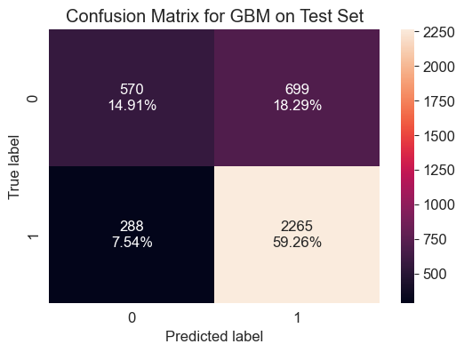

```python
# Confusion matrix for GBM on the test set
plot_confussion_matrix(gbm_original_tuned, X_test, y_test)
plt.title("Confusion Matrix for GBM on Test Set")
plt.show()
```

```python
# XGBoost performance on the test set
xgboost_over_test_performance = model_performance_classification(xgb_over_tuned, X_test, y_test)
xgboost_over_test_performance
```

|  | Accuracy | Recall | Precision | F1 |
| --- | --- | --- | --- | --- |
| 0 | 0.723967 | 0.938895 | 0.727245 | 0.819627 |

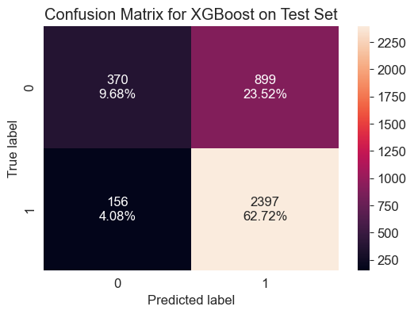

```python
# Confusion matrix for XGBoost on the test set
plot_confussion_matrix(xgb_over_tuned, X_test, y_test)
plt.title("Confusion Matrix for XGBoost on Test Set")
plt.show()
```

#### Observations:

- GBM model trained with the original data has the better F1 Score performance with unseen data, obtaining a score of 0.8210
- The XGBoost model trained with oversample data has a slight decrease in performance with unseen data, obtaining a score of 0.8196
- From the confusion matrices, GBM has a lower percentage of False Positives with 18.29%, will the XGBoost has 23.52% of False Positives.
- Both models are very good with False Negatives, GBM has 7.54% of False Negatives, while XGBoost has 4.08% of False Negatives.

**The Selected Model is GBM with the original training set.**

## Feature Importance

```python
# Obtain feature importances from the tuned GBM model
feature_importances_gbm = pd.DataFrame(
    gbm_original_tuned.feature_importances_,
    index=X_train.columns,
    columns=["Importance"]
).sort_values(by="Importance", ascending=False)
feature_importances_gbm["Importance %"] = (feature_importances_gbm["Importance"] * 100).round(2)
feature_importances_gbm
```

|  | Importance | Importance % |
| --- | --- | --- |
| education_of_employee_High School | 0.238336 | 23.83 |
| has_job_experience_Y | 0.145988 | 14.60 |
| education_of_employee_Master's | 0.117365 | 11.74 |
| prevailing_wage | 0.111767 | 11.18 |
| education_of_employee_Doctorate | 0.060138 | 6.01 |
| unit_of_wage_Year | 0.059804 | 5.98 |
| continent_Europe | 0.047368 | 4.74 |
| no_of_employees | 0.038971 | 3.90 |
| yr_of_estab | 0.035692 | 3.57 |
| region_of_employment_Midwest | 0.024974 | 2.50 |
| region_of_employment_West | 0.019429 | 1.94 |
| continent_Asia | 0.018032 | 1.80 |
| continent_North America | 0.017657 | 1.77 |
| full_time_position_Y | 0.016563 | 1.66 |
| region_of_employment_South | 0.014220 | 1.42 |
| region_of_employment_Northeast | 0.014024 | 1.40 |
| requires_job_training_Y | 0.009795 | 0.98 |
| continent_South America | 0.007417 | 0.74 |
| unit_of_wage_Week | 0.001530 | 0.15 |
| continent_Oceania | 0.000519 | 0.05 |
| unit_of_wage_Month | 0.000411 | 0.04 |

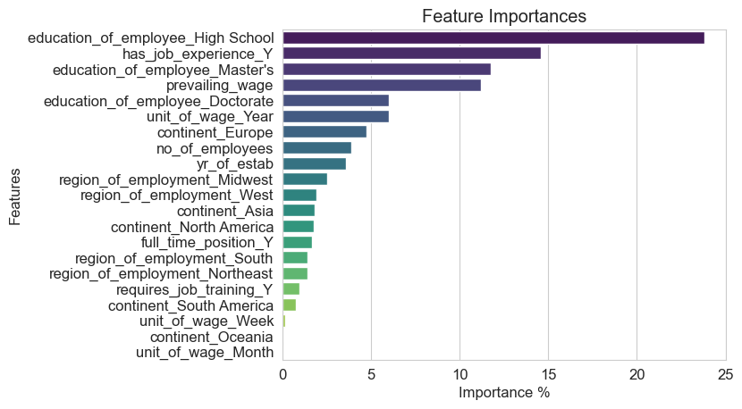

```python
# Plotting feature importances for the GBM model
plt.title("Feature Importances")
plt.xlabel("Importance %")
plt.ylabel("Features")
sns.barplot(
    x=feature_importances_gbm["Importance %"],
    y=feature_importances_gbm.index,
    palette="viridis"
)
plt.show()
```

#### Observations:

- The most important feature is the Education of Employee, applicants with degrees.
- Followed by the employee to have previous Job Experience.
- The prevailing wage will be the third most important feature.

# 9 - Actionable Insights and Recommendations

### Facilitate the process of visa approvals.

- The Gradient Boosting Model demonstrates an accuracy of 0.74, indicating strong overall performance. It generalizes effectively across training, validation, and test datasets, maintaining consistency in predictions.
- The model excels in minimizing false negatives, ensuring that qualified applicants are rarely denied. This is reflected in its recall score of 0.89 on unseen data, highlighting its ability to correctly identify skilled employees.
- However, the model exhibits a relatively higher incidence of false positives, increasing the likelihood of approving applicants who should have been denied. This is evident in its precision score of 0.76 on unseen data.

### Recommended profile for the applicants for whom the visa should be certified or denied

Visa applicants with the following profile have a higher likelihood of visa certification:

- **Education:** Higher education levels increase the probability of certification, particularly for applicants holding Master's or Doctorate degrees.
- **Job Experience:** Applicants with previous professional experience are more likely to receive certification.
- **Prevailing Wage:** Employees applying for positions with a prevailing wage above the median of $70,000 have a higher chance of certification.
- **Unit of Wage:** Positions offering yearly wages are more commonly certified.
- **Continent:** Applicants originating from Europe tend to have a greater likelihood of certification.
- **Region of Employment:** Applicants seeking employment in the Midwest region are more frequently certified.

Visa applicants with the following characteristics are less likely to receive certification:

- **Education:** Applicants who do not hold a degree face a higher probability of denial.
- **Work Experience:** Lack of prior job experience significantly increases the likelihood of application rejection.
- **Wage Unit:** Applications where the prevailing wage is expressed on an hourly basis are less likely to be approved.
- **Geographic Region:** Applicants from South America, North America, and Oceania have a lower probability of certification.

Power Ahead